# 🎓 Proyecto: Estadística para Data Science

¡Bienvenido al reto final!

Este proyecto tiene como objetivo integrar y aplicar todas las habilidades estadísticas adquiridas durante el curso. El trabajo se divide en 4 partes:

1. **Análisis Descriptivo (Dataset Libre):** Exploración profunda de un dataset de tu elección.
2. **Inferencia y Modelado (Dataset Libre):** Análisis de relaciones y predicción sobre tus datos.
3. **Regresión Lineal "From Scratch" (NumPy):** Implementación técnica de una regresión lineal simple usando solo matemáticas y NumPy.
4. **Series Temporales:** Análisis de tendencia y estacionalidad en datos simulados.

### Instrucciones Previas

Antes de comenzar, busca un dataset en [Kaggle](https://www.kaggle.com/) o una fuente confiable. Idealmente, debe tener:

- Al menos 5 variables (numéricas y categóricas).
- Un número razonable de filas (+1000).
- Una variable numérica clara que te gustaría predecir (Target/Y).

**Justificación de decisiones**

- Cada elección relevante (dataset, variables, métricas, supuestos estadísticos, etc.) debe estar brevemente justificada desde un punto de vista estadístico.

**Validación de supuestos**

- Siempre que se aplique un modelo o técnica estadística, se deberán comprobar explícitamente sus supuestos (normalidad, independencia, homocedasticidad, linealidad, estacionariedad, etc., según corresponda).

**Interpretación de resultados**

- No basta con calcular estadísticas o ajustar modelos: los resultados deben ser interpretados en lenguaje claro, conectándolos con el contexto de los datos.

**Reproducibilidad**

- El trabajo debe ser completamente reproducible: cualquier persona debería poder ejecutar el código y obtener los mismos resultados sin modificaciones manuales.

## PARTE 1: Análisis Descriptivo (Dataset Propio)

**Objetivo:** Comprender la naturaleza de tus datos antes de modelar.

**Requisitos:**

1. **Carga y Vista General:** Importa pandas, carga tu CSV y muestra las primeras filas, info y tipos de datos.
2. **Clasificación de Variables:** Identifica explícitamente cuáles son Nominales, Ordinales, Discretas y Continuas.
3. **Estadísticos Descriptivos:** Usa `.describe()` e interpreta la media vs mediana (¿Hay sesgo?).
4. **Detección de Outliers:** Identifica valores atípicos en tus variables numéricas usando Boxplots y el criterio del Rango Intercuartílico (IQR).
5. **Visualización de Distribuciones:** Plotea histogramas para tus variables principales.

**Conclusión:** Escribe un breve párrafo resumiendo la calidad de tus datos (¿Hay nulos? ¿Outliers? ¿Sesgo?).

**Amplia el analisis:**

- **Análisis de valores nulos**  
  Identifica la cantidad y el porcentaje de valores nulos por variable. Reflexiona brevemente sobre si su presencia parece aleatoria o estructural.
- **Comparación entre variables numéricas**  
  Selecciona al menos dos variables numéricas y analiza si presentan escalas o rangos muy distintos, comentando posibles implicaciones para futuros modelos.

  También se debe valorar como son los valores de las diferentes metricas para diferentes categorías dentro de tu data set. ej Diferencias por genero, edad, zona geográfica ...
- **Asimetría y curtosis**  
  Calcula la asimetría (skewness) de al menos una variable numérica e interpreta su relación con la forma observada en el histograma.
- **Outliers: impacto potencial**  
  Para una variable con outliers detectados, discute brevemente cómo podrían afectar al análisis inferencial o a un modelo predictivo posterior.
- **Calidad global del dataset**  
  Amplía la conclusión final incorporando una valoración general de si el dataset está “listo para modelar” o si requeriría una fase adicional de limpieza y transformación.

```python
# TU CÓDIGO AQUÍ - PARTE 1

import pandas as pd
import numpy as np
import matplotlib.pyplot as plt
import seaborn as sns

# Scripts creados para la optimización
from utils.clean_pipeline import map_cities, decoding_data, data_transform
from  utils.utils_general import card_tipo, cols_observation, skew_kurt
from utils.graphs_pipeline import plot_combined_graphs, var_graph

# Configuración visual
plt.style.use('seaborn-v0_8-whitegrid')
```

### 1. **Cargar datos**

```python
# 1. Cargar datos
df = pd.read_csv('./data/Sample_NYC_Taxi_Analysis.csv')
df.head(10)
```

|  | VendorID | tpep_pickup_datetime | tpep_dropoff_datetime | passenger_count | trip_distance | RatecodeID | store_and_fwd_flag | PULocationID | DOLocationID | payment_type | ... | improvement_surcharge | total_amount | congestion_surcharge | Airport_fee | cbd_congestion_fee | duration_min | speed_mph | pickup_hour | day_of_week | is_weekend |
| --- | --- | --- | --- | --- | --- | --- | --- | --- | --- | --- | --- | --- | --- | --- | --- | --- | --- | --- | --- | --- | --- |
| 0 | 2 | 2025-07-17 16:03:30 | 2025-07-17 16:35:16 | 1 | 4.71 | 5 | N | 162 | 112 | 1 | ... | 1.0 | 64.03 | 2.5 | 0.0 | 0.75 | 31.766667 | 8.896118 | 16 | Thursday | False |
| 1 | 2 | 2025-04-10 16:05:43 | 2025-04-10 16:14:03 | 1 | 1.39 | 1 | N | 239 | 238 | 1 | ... | 1.0 | 18.17 | 2.5 | 0.0 | 0.00 | 8.333333 | 10.008000 | 16 | Thursday | False |
| 2 | 2 | 2025-07-21 16:46:42 | 2025-07-21 16:52:43 | 1 | 0.74 | 1 | N | 113 | 249 | 1 | ... | 1.0 | 16.45 | 2.5 | 0.0 | 0.75 | 6.016667 | 7.379501 | 16 | Monday | False |
| 3 | 2 | 2025-03-07 23:20:00 | 2025-03-07 23:45:32 | 1 | 7.30 | 1 | N | 234 | 33 | 1 | ... | 1.0 | 50.79 | 2.5 | 0.0 | 0.75 | 25.533333 | 17.154047 | 23 | Friday | False |
| 4 | 2 | 2025-04-05 21:54:33 | 2025-04-05 22:00:19 | 2 | 0.68 | 1 | N | 249 | 234 | 1 | ... | 1.0 | 12.95 | 2.5 | 0.0 | 0.75 | 5.766667 | 7.075145 | 21 | Saturday | True |
| 5 | 2 | 2025-04-29 13:12:03 | 2025-04-29 13:14:20 | 1 | 0.24 | 1 | N | 237 | 237 | 1 | ... | 1.0 | 10.50 | 2.5 | 0.0 | 0.00 | 2.283333 | 6.306569 | 13 | Tuesday | False |
| 6 | 2 | 2025-10-17 13:28:53 | 2025-10-17 13:48:49 | 1 | 2.38 | 1 | N | 142 | 236 | 1 | ... | 1.0 | 24.85 | 2.5 | 0.0 | 0.75 | 19.933333 | 7.163880 | 13 | Friday | False |
| 7 | 2 | 2025-09-16 23:09:57 | 2025-09-16 23:22:06 | 1 | 1.45 | 1 | N | 170 | 68 | 1 | ... | 1.0 | 21.42 | 2.5 | 0.0 | 0.75 | 12.150000 | 7.160494 | 23 | Tuesday | False |
| 8 | 2 | 2025-01-06 12:26:57 | 2025-01-06 12:38:31 | 1 | 5.12 | 1 | N | 239 | 244 | 2 | ... | 1.0 | 26.60 | 2.5 | 0.0 | 0.00 | 11.566667 | 26.559078 | 12 | Monday | False |
| 9 | 2 | 2025-10-23 22:00:06 | 2025-10-23 22:21:30 | 2 | 1.55 | 1 | N | 230 | 233 | 1 | ... | 1.0 | 25.15 | 2.5 | 0.0 | 0.75 | 21.400000 | 4.345794 | 22 | Thursday | False |

10 rows × 25 columns

### 2. **Información del dataset**

El dataset reúne información del sistema de **taxis amarillos de la ciudad de Nueva York**. Este conjunto de datos contiene un registro detallado de los viajes en taxi de 2025 , ofreciendo información detallada sobre la movilidad urbana, la eficiencia del tráfico y el comportamiento económico de los pasajeros.

Este dataset es extraído en este [enlace](https://www.kaggle.com/datasets/aryanpatel212/cleaned-nyc-taxi-trip-data-2025-sample) desde la plataforma de Kaggle.

A continuación detallo información detallada de la decripciçon de cada variables:

| Variable | Descripción |
| --- | --- |
| `VendorID` | Código que indica el proveedor de TPEP que proporcionó el registro: 1 = Creative Mobile Technologies, LLC, 2 = Curb Mobility, LLC, 6 = Myle Technologies Inc |
| `tpep_pickup_datetime` | Fecha y hora en que se activó el medidor |
| `tpep_dropoff_datetime` | Fecha y hora en que se desconectó el medidor |
| `passenger_count` | Número de pasajeros en el vehículo (ingresado por el conductor) |
| `trip_distance` | Distancia del viaje transcurrida en millas informada por el taxímetro |
| `RatecodeID` | Código de tarifa final vigente al final del viaje: 1=Estándar, 2=JFK, 3=Newark, 4=Nassau o Westchester, 5=Negotiated fare, 99=Null/unknown |
| `store_and_fwd_flag` | Indica si el registro del viaje se mantuvo en la memoria del vehículo antes del envío (Y = almacenar y reenviar; N = no es un viaje almacenado y reenviado) |
| `PULocationID` | Zona de Taxi TLC en la que se encontraba activado el taxímetro |
| `DOLocationID` | Zona de Taxi TLC en la cual el taxímetro se encontraba desactivado |
| `payment_type` | código numérico que indica cómo pagó el pasajero: 0 = Viaje con tarifa flexible ,1 = Tarjeta de crédito, 2 = Efectivo, 3 = Sin cargo, 4 = Disputa |
| `fare_amount` | Tarifa por tiempo y distancia calculada por el taxímetro |
| `extra` | Extras y recargos varios |
| `mta_tax` | Impuesto MTA de $0,50 que se activa automáticamente en función de la tarifa medida en uso |
| `tip_amount` | Monto de la propina. (Nota: Este campo se completa automáticamente para propinas con tarjeta de crédito. No se incluyen las propinas en efectivo) |
| `tolls_amount` | Importe total de todos los peajes pagados en el viaje |
| `improvement_surcharge` | Recargo por mejoras para viajes en la bajada de bandera |
| `total_amount` | Importe total cobrado a los pasajeros. No incluye propinas en efectivo |
| `congestion_surcharge` | Total recaudado en el viaje por el recargo por congestión del estado de Nueva York |
| `Airport_fee` | $1.25 solo para recoger en los aeropuertos LaGuardia y John F. Kennedy |
| `cbd_congestion_fee` | Tarifa por viaje para la Zona de Alivio de Congestión de la MTA |
| `duration_min` | Duración del viaje en minutos |
| `speed_mph` | Velocidad promedio |
| `pickup_hour` | Hora donde el taxímetro se ha activado |
| `day_of_week` | Día de la semana |
| `is_weekend` | Si es fin de semana o no |

```python
# Primer vistazo para ver posibles nulos y tipos de datos
df.info()
```

```
<class 'pandas.core.frame.DataFrame'>
RangeIndex: 50000 entries, 0 to 49999
Data columns (total 25 columns):
 #   Column                 Non-Null Count  Dtype
---  ------                 --------------  -----
 0   VendorID               50000 non-null  int64
 1   tpep_pickup_datetime   50000 non-null  object
 2   tpep_dropoff_datetime  50000 non-null  object
 3   passenger_count        50000 non-null  int64
 4   trip_distance          50000 non-null  float64
 5   RatecodeID             50000 non-null  int64
 6   store_and_fwd_flag     50000 non-null  object
 7   PULocationID           50000 non-null  int64
 8   DOLocationID           50000 non-null  int64
 9   payment_type           50000 non-null  int64
```

[output cut: 17 more lines]

*Primeras observaciones*:

- Aparentemente no hay nulos reconocibles, exceptuando en `Airport_fee`.
- Hay muchas variables de tipo numérico, sin embargo, es preferible verlo en profundidad cada una de ellas

### 3. **Clasificación de Variables:**

```python
df_tipo = card_tipo(df, umbral_continua=4)
df_tipo
```

|  | Unique_values | %_Card | Tipo | tipo_sugerido |
| --- | --- | --- | --- | --- |
| VendorID | 3 | 0.006 | int64 | Categorica |
| tpep_pickup_datetime | 49949 | 99.898 | object | Numerica continua |
| tpep_dropoff_datetime | 49949 | 99.898 | object | Numerica continua |
| passenger_count | 7 | 0.014 | int64 | Categorica |
| trip_distance | 2136 | 4.272 | float64 | Numerica continua |
| RatecodeID | 6 | 0.012 | int64 | Categorica |
| store_and_fwd_flag | 2 | 0.004 | object | Binaria |
| PULocationID | 234 | 0.468 | int64 | Numerica discreta |
| DOLocationID | 244 | 0.488 | int64 | Numerica discreta |
| payment_type | 5 | 0.01 | int64 | Categorica |
| fare_amount | 3950 | 7.9 | float64 | Numerica continua |
| extra | 27 | 0.054 | float64 | Numerica discreta |
| mta_tax | 3 | 0.006 | float64 | Categorica |
| tip_amount | 1647 | 3.294 | float64 | Numerica discreta |
| tolls_amount | 70 | 0.14 | float64 | Numerica discreta |
| improvement_surcharge | 3 | 0.006 | float64 | Categorica |
| total_amount | 6165 | 12.33 | float64 | Numerica continua |
| congestion_surcharge | 2 | 0.004 | float64 | Binaria |
| Airport_fee | 2 | 0.004 | float64 | Binaria |
| cbd_congestion_fee | 2 | 0.004 | float64 | Binaria |
| duration_min | 3993 | 7.986 | float64 | Numerica continua |
| speed_mph | 38443 | 76.886 | float64 | Numerica continua |
| pickup_hour | 24 | 0.048 | int64 | Numerica discreta |
| day_of_week | 7 | 0.014 | object | Categorica |
| is_weekend | 2 | 0.004 | bool | Binaria |

```python
# Instancio posibles variables_cat y variables_num
variables_num = {col:df[col].dtype for col in df_tipo.index if df_tipo.loc[col]['tipo_sugerido'].startswith('Numerica')}
variables_num
```

```
{'tpep_pickup_datetime': dtype('O'),
 'tpep_dropoff_datetime': dtype('O'),
 'trip_distance': dtype('float64'),
 'PULocationID': dtype('int64'),
 'DOLocationID': dtype('int64'),
 'fare_amount': dtype('float64'),
 'extra': dtype('float64'),
 'tip_amount': dtype('float64'),
 'tolls_amount': dtype('float64'),
 'total_amount': dtype('float64'),
 'duration_min': dtype('float64'),
 'speed_mph': dtype('float64'),
 'pickup_hour': dtype('int64')}
```

*Observaciones:*

Como hemos investigado cada una de las variables, viendo este resumen de la tipología de las variables, podemos concluir que:

- Dentro de las variables tificadas como **numéricas**:
  - Se puede relacionar: `tpep_pickup_datetime`, `tpep_dropoff_datetime` y `pickup_hour` ya que son series temporales, sin embargo, están tipificadas como numéricas. ¿Tiene relación con `duration_min`?
  - Descodificaremos estas variables numéricas ya que se refieren a códigos de localización: `PULocationID` y `DOLocationID`.

```python
variables_cat = {col:df[col].dtype for col in df_tipo.index if df_tipo.loc[col]['tipo_sugerido'] in ['Categorica', 'Binaria']}
print(variables_cat)
print('Número de variables_cat:', len(variables_cat))
tipo_num = [col for col in variables_cat if df[col].dtype in ['int64', 'float64']]
print('Variables categóricas de tipo numérico:', tipo_num)
print('Número de variables categóricas de tipo numérico:', len(tipo_num))
```

```
{'VendorID': dtype('int64'), 'passenger_count': dtype('int64'), 'RatecodeID': dtype('int64'), 'store_and_fwd_flag': dtype('O'), 'payment_type': dtype('int64'), 'mta_tax': dtype('float64'), 'improvement_surcharge': dtype('float64'), 'congestion_surcharge': dtype('float64'), 'Airport_fee': dtype('floa…
Número de variables_cat: 12
Variables categóricas de tipo numérico: ['VendorID', 'passenger_count', 'RatecodeID', 'payment_type', 'mta_tax', 'improvement_surcharge', 'congestion_surcharge', 'Airport_fee', 'cbd_congestion_fee']
Número de variables categóricas de tipo numérico: 9
```

- Dentro de las variables tipificadas como **categóricas**:
  - Tenemos 12 variables, 9 son numéricas dado en el DF.
  - Observaremos en más profundidad: `passenger_count`, `mta_tax`, `improvement_surcharge`, `congestion_surcharge`, `Airport_fee`, `cbd_congestion_fee`.
  - Descodificaremos esos números en categorías ya que no son ordinales, sino nominales como: `VendorID`, `RatecodeID`, `payment_type`.
  - Investigación de nulos en `Airport_fee`

### 4. **Tratamiento de datos**

Antes de realizar cualquier análisis, ya que el dataset cuenta con posibles variables categóricas que son de tipo numérico, se realizará un tratamiento de datos para poder realizar un análisis descriptivo óptimo.

#### **Tratamiento de `tpep_pickup_datetime`, `tpep_dropoff_datetime`, `pickup_hour` y `duration_min`**

```python
df[['tpep_pickup_datetime', 'tpep_dropoff_datetime', 'pickup_hour', 'duration_min', 'day_of_week', 'is_weekend']]
```

|  | tpep_pickup_datetime | tpep_dropoff_datetime | pickup_hour | duration_min | day_of_week | is_weekend |
| --- | --- | --- | --- | --- | --- | --- |
| 0 | 2025-07-17 16:03:30 | 2025-07-17 16:35:16 | 16 | 31.766667 | Thursday | False |
| 1 | 2025-04-10 16:05:43 | 2025-04-10 16:14:03 | 16 | 8.333333 | Thursday | False |
| 2 | 2025-07-21 16:46:42 | 2025-07-21 16:52:43 | 16 | 6.016667 | Monday | False |
| 3 | 2025-03-07 23:20:00 | 2025-03-07 23:45:32 | 23 | 25.533333 | Friday | False |
| 4 | 2025-04-05 21:54:33 | 2025-04-05 22:00:19 | 21 | 5.766667 | Saturday | True |
| ... | ... | ... | ... | ... | ... | ... |
| 49995 | 2025-09-09 18:14:11 | 2025-09-09 19:14:53 | 18 | 60.700000 | Tuesday | False |
| 49996 | 2025-02-14 23:20:54 | 2025-02-14 23:31:24 | 23 | 10.500000 | Friday | False |
| 49997 | 2025-06-16 15:58:07 | 2025-06-16 16:22:05 | 15 | 23.966667 | Monday | False |
| 49998 | 2025-06-10 16:14:20 | 2025-06-10 16:53:16 | 16 | 38.933333 | Tuesday | False |
| 49999 | 2025-02-03 16:09:26 | 2025-02-03 16:12:01 | 16 | 2.583333 | Monday | False |

50000 rows × 6 columns

**Conclusiones**:

- Eliminación de `tpep_dropoff_datetime` y `is_weekend` ya que no nos da mucha información teniendo ya una variable que indica la duración y el día de la semana
- Eliminación de `is_weekend` ya que en `day_of_week` tenemos los días de la semana.
- Cambiamos el tipo a `datatime` de `tpep_pickup_datetime`

En definitiva, nos quedamos con `tpep_pickup_datetime` y `duration_min`.

En `clean_pipeline.py` creamos un **Pipeline** de limpieza donde iremos insertando todas las transformaciones que se decida elaborar.

- Añadimos esta transformación en nuestro pipeline de limpieza.

#### **Descodificación de `PULocationID` y `DOLocationID`**

En primer lugar, vemos los valores que contienen ambas variables.

```python
cols_observation(df, ['PULocationID', 'DOLocationID'])
```

```
Para "PULocationID":

Nulos:
0

Valores:
PULocationID
161    2277
237    2261
132    2049
236    2009
186    1635
       ...
115       1
5         1
118       1
156       1
6         1
Name: count, Length: 234, dtype: int64

Valores únicos:
[162 239 113 234 249 237 142 170 230 132 100 137 231 236 164  68  70 186
  24 229 141 140  75 238  13 263 144  43 148 157 151 143 247 161  90 193
  79 114 246 138  76 163 211  97 107 233 174  48 177  87 158 188   7  41
  91 242 125  25 224 226  50  17 215  40  88 200   4 116 261 255  66 183
  35 166  36  74  82 258  42 262 130  89  20 209 195  56  83 180 244 127
 225  45 198 165 232 155 147  55  33  65  69 112  72 106  37 197  26 131
 182  77 168 160 213  18  12  61 223 235 152 256 181 184 133 145  39 216
 196 159  47 134  49 243 189  71 203 217 192 119  10  80  60  22 115 219
 146  67 210 179 191 260  95  64  73 218 102  93 228 259 108 173  78  94
 205 254 150  62 135 149 212  52  14 136 124  11 185 250 123  85  81  86
 220 202 169 171 227 241 153  19  63 126 129 128 190 248  92  34 201  32
 257 253  28 208 167  38  21  53 117  31 122 252 101 222 156 118 175  54
  51   5   3  29  15 121 214  57  16   9 120   1 194 240  58  46 172   6]
Para "DOLocationID":

Nulos:
0

Valores:
```

[output cut: 14 more lines]

```
Valores únicos:
[112 238 249  33 234 237 236  68 244 233 243 162 186 161  50 209 148  24
 163 142 137 140 127 141 143 138  61   9  65  87 164 100 231  82  69  13
 145 246 252 113 239 211 158 107 170 230 166  90 263 114  37 229  72 195
  26 152 261  74  55   4  48 132 108 151 260  88 193  79  56 232  43  97
  75 182 190 144 133 205   7 181  89 224 262   1  66 179  25  45  51 210
 180  18  67 125 124  11 120  86  52 135 129  42  41  76  91  70 222 150
 256  95 157  85 227 174  80 106 228  29 183 155 149 198 167 255 116  39
 213 134 208 216  58  38  49  53 126 223  14 189 225 177 215 197  47 168
 226  36 130 160 159 136 188  62 241  28  17 194 258  10 242 175 219  94
  16  35 202  78  71 204 123 200 217 218 191  92  20 146  22  63 173 254
  32 131 117 122 165  54  40 212  64  77 121   3 119 196 257 147 247 248
  12  19 250  93 201 169 203 102 139 235  15  21 220 128  83 178  81 221
  98 192 154  34 185 259  60 118 171 214 207  73 176 240  96   6  31  46
  57 253  23 111 101  84 153  27   8  59]
```

Las variables `PULocationID` y `DOLocationID` son localizaciones dentro de la zona TLC de taxis en el estado de Nueva York. Son numéricas pero para poder entenderlo mejor, vamos a mapear esos códigos a la zona que representa.

```python
df_zonas = pd.read_csv('./data/taxi_zone_lookup.csv')
df_zonas.head()
```

|  | LocationID | Borough | Zone | service_zone |
| --- | --- | --- | --- | --- |
| 0 | 1 | EWR | Newark Airport | EWR |
| 1 | 2 | Queens | Jamaica Bay | Boro Zone |
| 2 | 3 | Bronx | Allerton/Pelham Gardens | Boro Zone |
| 3 | 4 | Manhattan | Alphabet City | Yellow Zone |
| 4 | 5 | Staten Island | Arden Heights | Boro Zone |

```python
df_bronx = df_zonas.loc[df_zonas['Borough'] == 'Bronx']
df_bronx.groupby(['Borough', 'Zone'])['LocationID'].unique()
```

```
Borough  Zone
Bronx    Allerton/Pelham Gardens                  [3]
         Bedford Park                            [18]
         Belmont                                 [20]
         Bronx Park                              [31]
         Bronxdale                               [32]
         City Island                             [46]
         Claremont/Bathgate                      [47]
         Co-Op City                              [51]
         Country Club                            [58]
         Crotona Park                            [59]
         Crotona Park East                       [60]
         East Concourse/Concourse Village        [69]
         East Tremont                            [78]
         Eastchester                             [81]
         Fordham South                           [94]
         Highbridge                             [119]
         Hunts Point                            [126]
         Kingsbridge Heights                    [136]
         Longwood                               [147]
         Melrose South                          [159]
         Morrisania/Melrose                     [167]
         Mott Haven/Port Morris                 [168]
         Mount Hope                             [169]
         Norwood                                [174]
         Parkchester                            [182]
         Pelham Bay                             [183]
         Pelham Bay Park                        [184]
         Pelham Parkway                         [185]
         Rikers Island                          [199]
         Riverdale/North Riverdale/Fieldston    [200]
         Schuylerville/Edgewater Park           [208]
         Soundview/Bruckner                     [212]
         Soundview/Castle Hill                  [213]
         Spuyten Duyvil/Kingsbridge             [220]
         University Heights/Morris Heights      [235]
         Van Cortlandt Park                     [240]
         Van Cortlandt Village                  [241]
         Van Nest/Morris Park                   [242]
         West Concourse                         [247]
         West Farms/Bronx River                 [248]
         Westchester Village/Unionport          [250]
         Williamsbridge/Olinville               [254]
         Woodlawn/Wakefield                     [259]
Name: LocationID, dtype: object
```

Se observa que `LocationID` corresponde a `Zone`, por lo que los códigos de `PULocationID` y `DOLocationID` corresponden a las zonas de este dataset. Esas zonas, a su vez, a diferentes estados, que también las uniremos ya que a la hora de analizar son más conocidas.

Nuestro **Pipeline** de limpieza, de momento, incluye:

- Limpieza de fechas
- Descodificación de las localizaciones.

#### **Observación de `passenger_count`, `mta_tax`, `improvement_surcharge`, `congestion_surcharge`, `Airport_fee` y `cbd_congestion_fee`**

```python
cols_observation(df, ['passenger_count', 'mta_tax', 'improvement_surcharge', 'congestion_surcharge',
                      'Airport_fee', 'cbd_congestion_fee'])
```

```
Para "passenger_count":

Nulos:
0

Valores:
passenger_count
1    41757
2     5512
3     1310
4      815
0      281
5      206
6      119
Name: count, dtype: int64

Valores únicos:
[1 2 0 4 3 5 6]
Para "mta_tax":

Nulos:
0

Valores:
mta_tax
0.50    49637
0.00      362
3.75        1
Name: count, dtype: int64

Valores únicos:
[0.   0.5  3.75]
Para "improvement_surcharge":

Nulos:
0

Valores:
improvement_surcharge
1.0    49151
```

[output cut: 32 more lines]

```
Valores únicos:
[0.   1.75  nan]
Para "cbd_congestion_fee":

Nulos:
0

Valores:
cbd_congestion_fee
0.75    36703
0.00    13297
Name: count, dtype: int64

Valores únicos:
[0.75 0.  ]
```

*Observaciones*:

- `passenger_count` es una variable numérica discreta.
- `mta_tax`, `improvement_surcharge`, `congestion_surcharge` y `cbd_congestion_fee` las valoramos como numéricas ya que se tratan de pagos por impuestos o recargo.
- `Airport_fee` tiene un 20% de nulos, la observaremos con más detenimiento.

#### **Descodificación de `VendorID`, `RatecodeID` y `payment_type`**

```python
cols_observation(df, ['VendorID', 'RatecodeID', 'payment_type'])
```

```
Para "VendorID":

Nulos:
0

Valores:
VendorID
2    39363
1    10620
6       17
Name: count, dtype: int64

Valores únicos:
[2 1 6]
Para "RatecodeID":

Nulos:
0

Valores:
RatecodeID
1     47391
2      1419
99      840
5       211
3       128
4        11
Name: count, dtype: int64

Valores únicos:
[ 5  1  2 99  3  4]
Para "payment_type":

Nulos:
0

Valores:
payment_type
1    34880
0     9669
2     4714
4      583
3      154
Name: count, dtype: int64

Valores únicos:
[1 2 0 4 3]
```

Cómo se ha hecho una investigación previa de la información de cada variable descodificaremos cada categoría de la siguiente forma:

- Para `VendorID`:
  - 1 -> Creative Mobile Technologies.
  - 2 -> Curb Mobility.
  - 6 -> Myle Technologies Inc.
- Para `RatecodeID`:
  - 1 -> Estándar.
  - 2 -> JFK.
  - 3 -> Newark.
  - 4 -> Nassau o Westchester
  - 5 -> Negotiated fare
  - 99 -> Null/unknown
- Para `payment_type`:
  - 0 -> Viaje con tarifa flexible.
  - 1 -> Tarjeta de crédito.
  - 2 -> Efectivo.
  - 3 -> Sin cargo.
  - 4 -> Disputa

Nuestro **Pipeline** de limpieza, de momento, incluye:

- Limpieza de fechas
- Descodificación de las localizaciones, del proveedor, del tipo de tarifa y del tipo de pago.
- Renombre de columnas para que sean más descriptivas

#### **Tratamiento de nulos**

##### En `Airport_fee`

Los dos aeropuertos de Nueva York pertenecen al estado de Queens. Esto es importante a la hora de tratar los nulos. Aunque esto no significa que los clientes que se hayan recogido en este estado todos vengan del aeropuerto y tengan que tener este recargo.

```python
df_copy = df.copy()
```

```python
# Porcentaje de nulos
df_copy['Airport_fee'].isna().sum() / len(df_copy) * 100
```

```
19.338
```

```python
# Mapeo los códigos de las localizaciones
df_map = map_cities(df_copy, df_zonas, right_on='LocationID', merge_cols=['LocationID', 'Borough', 'Zone'], cols_origin=['PULocationID', 'DOLocationID'])
df_map_ = df_map[['Airport_fee', 'PU_city', 'DO_city']]
df_map_ # Me quedo con estas variables que me interesan
```

|  | Airport_fee | PU_city | DO_city |
| --- | --- | --- | --- |
| 0 | 0.00 | Midtown East | Greenpoint |
| 1 | 0.00 | Upper West Side South | Upper West Side North |
| 2 | 0.00 | Greenwich Village North | West Village |
| 3 | 0.00 | Union Sq | Brooklyn Heights |
| 4 | 0.00 | West Village | Union Sq |
| ... | ... | ... | ... |
| 49995 | NaN | Lincoln Square East | JFK Airport |
| 49996 | 0.00 | Greenwich Village North | Lower East Side |
| 49997 | 0.00 | East Chelsea | World Trade Center |
| 49998 | 1.75 | LaGuardia Airport | Jamaica |
| 49999 | 0.00 | Upper West Side South | Upper West Side North |

50000 rows × 3 columns

```python
# Veo cuáles es el origen si en el viaje se aplica la tariga de aeropuerto
df_map_.loc[df_map_['Airport_fee'] == 1.75, 'PU_city'].value_counts()
```

```
PU_city
JFK Airport                 1946
LaGuardia Airport           1378
East Elmhurst                106
Steinway                       1
Financial District North       1
College Point                  1
Name: count, dtype: int64
```

```python
# Desgrano el destino de aquellas zonas que no sean la zona aeropuertaria
origin = ['East Elmhurst', 'Steinway', 'Financial District North', 'College Point']
for col in origin:
   print( df_map_.loc[(df_map_['Airport_fee'] == 1.75) & (df_map_['PU_city'] == col)].value_counts())
   print('**'*20)
```

```
Airport_fee  PU_city        DO_city
1.75         East Elmhurst  Midtown East                      7
                            Lenox Hill West                   6
                            Midtown North                     5
                            Midtown South                     4
                            Times Sq/Theatre District         4
                                                             ..
                            Lincoln Square East               1
                            Long Island City/Hunters Point    1
                            Bloomingdale                      1
                            Lower East Side                   1
                            Long Island City/Queens Plaza     1
Name: count, Length: 61, dtype: int64
Airport_fee  PU_city   DO_city
1.75         Steinway  Union Sq    1
Name: count, dtype: int64
Airport_fee  PU_city                   DO_city
1.75         Financial District North  JFK Airport    1
Name: count, dtype: int64
Airport_fee  PU_city        DO_city
1.75         College Point  Penn Station/Madison Sq West    1
Name: count, dtype: int64
```

La tarifa de aeropuerto solo se aplica si el taxi recoge al cliente en los dos aeropuertos (JFK Airport y LaGuardia Airport).

- Se ve que en **East Elmhurst** hay cobrados 106 viajes. Investigando un poco esto se debe a la proximidad de esta zona a los aeropuertos.
- En **Steinway** y **College Point** los destinos tamppoco corresponden a aeropuertos por lo que seguramente sea una tarifa aplicada erróneamente.
- En **Financial District North** el destino es **JFK Airport** por lo que aquí sí puede ser coherente la tarifa aplicada.

Podemos tratar los nulos de la siguiente manera:

- Los viajes con **ORIGEN** y **DESTINO** a uno de los dos aeropuertos, imputamos los nulos con el precio de la tarifa.
- Los viajes que sea ni con origen ni con destino a uno de los dos aeropuertos, lo ponemos a 0.

```python
df_nulos = df_map_.loc[df_map_['Airport_fee'].isna()]
origen_aero = df_nulos.loc[(df_nulos['PU_city'] == 'JFK Airport') | (df_nulos['PU_city'] == 'LaGuardia Airport')]
origen_aero
```

|  | Airport_fee | PU_city | DO_city |
| --- | --- | --- | --- |
| 377 | NaN | LaGuardia Airport | Lenox Hill West |
| 1800 | NaN | LaGuardia Airport | Flatbush/Ditmas Park |
| 8771 | NaN | LaGuardia Airport | Bay Ridge |
| 10957 | NaN | LaGuardia Airport | Roosevelt Island |
| 11439 | NaN | LaGuardia Airport | Crown Heights North |
| 14531 | NaN | LaGuardia Airport | Yorkville West |
| 16138 | NaN | JFK Airport | Bay Ridge |
| 16755 | NaN | JFK Airport | Starrett City |
| 19174 | NaN | LaGuardia Airport | Sunnyside |
| 21167 | NaN | JFK Airport | West Chelsea/Hudson Yards |
| 22673 | NaN | LaGuardia Airport | Central Park |
| 24468 | NaN | LaGuardia Airport | East Chelsea |
| 26921 | NaN | JFK Airport | Saint Albans |
| 26978 | NaN | LaGuardia Airport | Yorkville East |
| 30462 | NaN | LaGuardia Airport | Gramercy |
| 35632 | NaN | JFK Airport | East New York/Pennsylvania Avenue |
| 36086 | NaN | JFK Airport | Yorkville West |
| 39717 | NaN | JFK Airport | Times Sq/Theatre District |
| 41853 | NaN | LaGuardia Airport | Upper East Side North |

```python
len(origen_aero) # 19 nulos donde el origen es uno de los dos aeropuertos
```

```
19
```

```python
destino_aero = df_nulos.loc[(df_nulos['DO_city'] == 'JFK Airport') | (df_nulos['DO_city'] == 'LaGuardia Airport')]
destino_aero # 100 nulos donde el destino es uno de los dos aeropuertos
```

|  | Airport_fee | PU_city | DO_city |
| --- | --- | --- | --- |
| 975 | NaN | DUMBO/Vinegar Hill | JFK Airport |
| 1110 | NaN | Kips Bay | LaGuardia Airport |
| 1235 | NaN | Garment District | LaGuardia Airport |
| 2060 | NaN | East Village | LaGuardia Airport |
| 2329 | NaN | Upper West Side North | LaGuardia Airport |
| ... | ... | ... | ... |
| 48018 | NaN | Upper West Side South | LaGuardia Airport |
| 48223 | NaN | Ozone Park | JFK Airport |
| 48936 | NaN | Upper East Side North | LaGuardia Airport |
| 49507 | NaN | Central Harlem | LaGuardia Airport |
| 49995 | NaN | Lincoln Square East | JFK Airport |

100 rows × 3 columns

```python
no_aero_or = df_nulos.loc[(df_nulos['PU_city'] != 'JFK Airport') & (df_nulos['PU_city'] != 'LaGuardia Airport')]
no_aero_or # 9650 nulos donde el origen no es uno de los dos aeropuertos
```

|  | Airport_fee | PU_city | DO_city |
| --- | --- | --- | --- |
| 16 | NaN | Upper East Side North | Midtown Center |
| 29 | NaN | East Harlem South | Inwood |
| 39 | NaN | Kips Bay | Downtown Brooklyn/MetroTech |
| 40 | NaN | Little Italy/NoLiTa | Financial District North |
| 44 | NaN | Murray Hill | TriBeCa/Civic Center |
| ... | ... | ... | ... |
| 49976 | NaN | Lincoln Square East | Times Sq/Theatre District |
| 49981 | NaN | Upper West Side South | Midtown Center |
| 49986 | NaN | West Village | Midtown East |
| 49990 | NaN | Midtown Center | Flatiron |
| 49995 | NaN | Lincoln Square East | JFK Airport |

9650 rows × 3 columns

```python
no_aero_des = df_nulos.loc[(df_nulos['DO_city'] != 'JFK Airport') & (df_nulos['DO_city'] != 'LaGuardia Airport')]
no_aero_des # 9569  nulos donde el destino no es uno de los dos aeropuertos
```

|  | Airport_fee | PU_city | DO_city |
| --- | --- | --- | --- |
| 16 | NaN | Upper East Side North | Midtown Center |
| 29 | NaN | East Harlem South | Inwood |
| 39 | NaN | Kips Bay | Downtown Brooklyn/MetroTech |
| 40 | NaN | Little Italy/NoLiTa | Financial District North |
| 44 | NaN | Murray Hill | TriBeCa/Civic Center |
| ... | ... | ... | ... |
| 49972 | NaN | Times Sq/Theatre District | Murray Hill |
| 49976 | NaN | Lincoln Square East | Times Sq/Theatre District |
| 49981 | NaN | Upper West Side South | Midtown Center |
| 49986 | NaN | West Village | Midtown East |
| 49990 | NaN | Midtown Center | Flatiron |

9569 rows × 3 columns

**Análisis de valores nulos en `Airport_fee`**  
Los valores nulos están directamente relacionados con la localización del origen y/o destino del viaje. Dado que esta tarifa solo se aplica en recogidas o destinos en los aeropuertos JFK y LaGuardia, la ausencia de valor en el resto de viajes es coherente con la naturaleza de la variable. Por tanto, estos valores nulos se consideran estructurales y no aleatorios.

Nuestro **Pipeline** de limpieza, de momento, incluye:

- Limpieza de fechas
- Descodificación de las localizaciones, del proveedor, del tipo de tarifa y del tipo de pago.
- Renombre de columnas para que sean más descriptivas
- Imputación de nulos en `Airport_fee`.

##### En `RatecodeID`

Investigando sobre el tipo de tarifa, tendremos en cuenta que:

- Las tarifas tipo `JFK` son aquellas que tiene como destino el aeropuerto JFK
- Las tarifas tipo `Newark` o `Nassau o Westchester` tienen como destinos LaGuardia Airport y Newark Airport
- El resto serían tarifas de tipo `Estandar`
- No podemos valorar aquellas que son de tipo `Negotiated fare`.

Por lo que tendremos en cuenta las 3 primeras

```python
# Retomo el DF mapeado con las localizaciones
df_filtred = df_map[['RatecodeID', 'PU_city', 'PU_Borough', 'DO_Borough', 'DO_city']] # Me quedo con estas variables
df_filtred.head()
```

|  | RatecodeID | PU_city | PU_Borough | DO_Borough | DO_city |
| --- | --- | --- | --- | --- | --- |
| 0 | 5 | Midtown East | Manhattan | Brooklyn | Greenpoint |
| 1 | 1 | Upper West Side South | Manhattan | Manhattan | Upper West Side North |
| 2 | 1 | Greenwich Village North | Manhattan | Manhattan | West Village |
| 3 | 1 | Union Sq | Manhattan | Brooklyn | Brooklyn Heights |
| 4 | 1 | West Village | Manhattan | Manhattan | Union Sq |

```python
df_filtred = decoding_data(df_filtred, ['RatecodeID']) # Descodifico
df_filtred.head()
```

|  | PU_city | PU_Borough | DO_Borough | DO_city | tariff_type |
| --- | --- | --- | --- | --- | --- |
| 0 | Midtown East | Manhattan | Brooklyn | Greenpoint | Negotiated fare |
| 1 | Upper West Side South | Manhattan | Manhattan | Upper West Side North | Estándar |
| 2 | Greenwich Village North | Manhattan | Manhattan | West Village | Estándar |
| 3 | Union Sq | Manhattan | Brooklyn | Brooklyn Heights | Estándar |
| 4 | West Village | Manhattan | Manhattan | Union Sq | Estándar |

```python
# Porcentaje de nulos
df_filtred['tariff_type'].isna().sum() / len(df_filtred) * 100
```

```
1.68
```

```python
df_nulls = df_filtred.loc[df_filtred['tariff_type'].isna()]
df_nulls
```

|  | PU_city | PU_Borough | DO_Borough | DO_city | tariff_type |
| --- | --- | --- | --- | --- | --- |
| 87 | East New York | Brooklyn | Brooklyn | East Flatbush/Remsen Village | NaN |
| 234 | Bedford | Brooklyn | Queens | Saint Albans | NaN |
| 292 | Riverdale/North Riverdale/Fieldston | Bronx | Manhattan | Midtown Center | NaN |
| 304 | Hamilton Heights | Manhattan | Manhattan | Murray Hill | NaN |
| 330 | Pelham Bay | Bronx | Manhattan | Midtown East | NaN |
| ... | ... | ... | ... | ... | ... |
| 49714 | Springfield Gardens North | Queens | Manhattan | Financial District South | NaN |
| 49754 | East Tremont | Bronx | Bronx | Bedford Park | NaN |
| 49858 | Midwood | Brooklyn | Manhattan | East Harlem South | NaN |
| 49859 | Canarsie | Brooklyn | Brooklyn | Crown Heights North | NaN |
| 49949 | Marine Park/Mill Basin | Brooklyn | Brooklyn | Prospect Heights | NaN |

840 rows × 5 columns

```python
df_nulls.loc[(df_nulls['DO_city'] == 'Newark Airport') | (df_nulls['DO_city'] == 'LaGuardia Airport')]
# No hay ningún nulo con esos destinos, por lo que no podemos imputar que sea la tarifa `Newark` o `Nassau o Westchester`
```

|  | PU_city | PU_Borough | DO_Borough | DO_city | tariff_type |
| --- | --- | --- | --- | --- | --- |

```python
df_nulls.loc[df_nulls['DO_city'] == 'JFK Airport'] # Tenemos uno que sí podemos imputar por la tarifa JFK
```

|  | PU_city | PU_Borough | DO_Borough | DO_city | tariff_type |
| --- | --- | --- | --- | --- | --- |
| 1481 | Boerum Hill | Brooklyn | Queens | JFK Airport | NaN |

```python
df_nulls.loc[~(df_nulls['DO_city'] == 'JFK Airport')] # DUDA: ¿Imputamos el resto (839) por la tarifa estándar?
```

|  | PU_city | PU_Borough | DO_Borough | DO_city | tariff_type |
| --- | --- | --- | --- | --- | --- |
| 87 | East New York | Brooklyn | Brooklyn | East Flatbush/Remsen Village | NaN |
| 234 | Bedford | Brooklyn | Queens | Saint Albans | NaN |
| 292 | Riverdale/North Riverdale/Fieldston | Bronx | Manhattan | Midtown Center | NaN |
| 304 | Hamilton Heights | Manhattan | Manhattan | Murray Hill | NaN |
| 330 | Pelham Bay | Bronx | Manhattan | Midtown East | NaN |
| ... | ... | ... | ... | ... | ... |
| 49714 | Springfield Gardens North | Queens | Manhattan | Financial District South | NaN |
| 49754 | East Tremont | Bronx | Bronx | Bedford Park | NaN |
| 49858 | Midwood | Brooklyn | Manhattan | East Harlem South | NaN |
| 49859 | Canarsie | Brooklyn | Brooklyn | Crown Heights North | NaN |
| 49949 | Marine Park/Mill Basin | Brooklyn | Brooklyn | Prospect Heights | NaN |

839 rows × 5 columns

**Análisis de valores nulos en `RatecodeID`**

- Estos valores nulos están asociados a la falta de clasificación explícita del tipo de tarifa. Mediante el análisis del destino del viaje, se imputará de manera fiable el único caso correspondiente a tarifa JFK, mientras que el resto se ha imputado como tarifa estándar, al no existir evidencia que permita asignar otro tipo. Esto indica nuevamente la presencia de valores nulos de carácter estructural.

Nuestro **Pipeline** de limpieza, finalmente, incluye:

- Limpieza de fechas
- Descodificación de las localizaciones, del proveedor, del tipo de tarifa y del tipo de pago.
- Renombre de columnas para que sean más descriptivas
- Imputación de nulos en `Airport_fee` y `RatecodeID`.

### 5. **Limpieza de datos**

```python
df_clean = data_transform(df, df_zonas)
```

```python
df_clean.head()
```

|  | tpep_pickup_datetime | passenger_count | trip_distance | store_and_fwd_flag | payment_type | fare_amount | extra | mta_tax | tip_amount | tolls_amount | ... | duration_min | speed_mph | pickup_hour | day_of_week | PU_city | PU_Borough | DO_city | DO_Borough | provider | tariff_type |
| --- | --- | --- | --- | --- | --- | --- | --- | --- | --- | --- | --- | --- | --- | --- | --- | --- | --- | --- | --- | --- | --- |
| 0 | 2025-07-17 16:03:30 | 1 | 4.71 | N | Tarjeta de crédito | 45.0 | 0.0 | 0.0 | 14.78 | 0.00 | ... | 31.766667 | 8.896118 | 16 | Thursday | Midtown East | Manhattan | Greenpoint | Brooklyn | Curb Mobility | Negotiated fare |
| 1 | 2025-04-10 16:05:43 | 1 | 1.39 | N | Tarjeta de crédito | 9.3 | 2.5 | 0.5 | 2.37 | 0.00 | ... | 8.333333 | 10.008000 | 16 | Thursday | Upper West Side South | Manhattan | Upper West Side North | Manhattan | Curb Mobility | Estándar |
| 2 | 2025-07-21 16:46:42 | 1 | 0.74 | N | Tarjeta de crédito | 7.2 | 2.5 | 0.5 | 2.00 | 0.00 | ... | 6.016667 | 7.379501 | 16 | Monday | Greenwich Village North | Manhattan | West Village | Manhattan | Curb Mobility | Estándar |
| 3 | 2025-03-07 23:20:00 | 1 | 7.30 | N | Tarjeta de crédito | 33.1 | 1.0 | 0.5 | 5.00 | 6.94 | ... | 25.533333 | 17.154047 | 23 | Friday | Union Sq | Manhattan | Brooklyn Heights | Brooklyn | Curb Mobility | Estándar |
| 4 | 2025-04-05 21:54:33 | 2 | 0.68 | N | Tarjeta de crédito | 7.2 | 1.0 | 0.5 | 0.00 | 0.00 | ... | 5.766667 | 7.075145 | 21 | Saturday | West Village | Manhattan | Union Sq | Manhattan | Curb Mobility | Estándar |

5 rows × 25 columns

```python
df_clean.info()
```

```
<class 'pandas.core.frame.DataFrame'>
RangeIndex: 50000 entries, 0 to 49999
Data columns (total 25 columns):
 #   Column                 Non-Null Count  Dtype
---  ------                 --------------  -----
 0   tpep_pickup_datetime   50000 non-null  datetime64[ns]
 1   passenger_count        50000 non-null  int64
 2   trip_distance          50000 non-null  float64
 3   store_and_fwd_flag     50000 non-null  object
 4   payment_type           50000 non-null  object
 5   fare_amount            50000 non-null  float64
 6   extra                  50000 non-null  float64
 7   mta_tax                50000 non-null  float64
 8   tip_amount             50000 non-null  float64
 9   tolls_amount           50000 non-null  float64
```

[output cut: 17 more lines]

### 6. **Estadísticos Descriptivos**

Antes de la clasificación final de nuestras variables realizaremos una descripción estadística para analizar en profundidad nuestras variables numéricas

```python
# Instancio las features categóricas y las numéricas
features_cat = [col for col in df_clean.columns if df_clean[col].dtype == 'object']
features_num = [col for col in df_clean.columns if col not in features_cat and col != 'tpep_pickup_datetime']
features_cat
```

```
['store_and_fwd_flag',
 'payment_type',
 'day_of_week',
 'PU_city',
 'PU_Borough',
 'DO_city',
 'DO_Borough',
 'provider',
 'tariff_type']
```

```python
features_num
```

```
['passenger_count',
 'trip_distance',
 'fare_amount',
 'extra',
 'mta_tax',
 'tip_amount',
 'tolls_amount',
 'improvement_surcharge',
 'total_amount',
 'congestion_surcharge',
 'Airport_fee',
 'cbd_congestion_fee',
 'duration_min',
 'speed_mph',
 'pickup_hour']
```

#### **`describe()`**

```python
df_clean[features_num].describe().T
```

|  | count | mean | std | min | 25% | 50% | 75% | max |
| --- | --- | --- | --- | --- | --- | --- | --- | --- |
| passenger_count | 50000.0 | 1.234300 | 0.661734 | 0.000000 | 1.000000 | 1.000000 | 1.000000 | 6.000000 |
| trip_distance | 50000.0 | 3.457453 | 4.159014 | 0.110000 | 1.100000 | 1.890000 | 3.700000 | 36.400000 |
| fare_amount | 50000.0 | 19.415738 | 15.856172 | 0.010000 | 9.300000 | 14.200000 | 22.600000 | 250.000000 |
| extra | 50000.0 | 1.304690 | 1.834198 | -0.750000 | 0.000000 | 0.000000 | 2.500000 | 12.500000 |
| mta_tax | 50000.0 | 0.496445 | 0.044818 | 0.000000 | 0.500000 | 0.500000 | 0.500000 | 3.750000 |
| tip_amount | 50000.0 | 3.045984 | 3.809350 | 0.000000 | 0.000000 | 2.450000 | 4.070000 | 101.170000 |
| tolls_amount | 50000.0 | 0.511533 | 1.981751 | 0.000000 | 0.000000 | 0.000000 | 0.000000 | 38.000000 |
| improvement_surcharge | 50000.0 | 0.983122 | 0.128538 | 0.000000 | 1.000000 | 1.000000 | 1.000000 | 1.000000 |
| total_amount | 50000.0 | 28.204689 | 19.991217 | 1.510000 | 16.630000 | 21.790000 | 30.780000 | 262.750000 |
| congestion_surcharge | 50000.0 | 1.856400 | 1.093070 | 0.000000 | 0.000000 | 2.500000 | 2.500000 | 2.500000 |
| Airport_fee | 50000.0 | 0.124320 | 0.449565 | 0.000000 | 0.000000 | 0.000000 | 0.000000 | 1.750000 |
| cbd_congestion_fee | 50000.0 | 0.550545 | 0.331378 | 0.000000 | 0.000000 | 0.750000 | 0.750000 | 0.750000 |
| duration_min | 50000.0 | 16.948983 | 13.405025 | 1.000000 | 8.300000 | 13.333333 | 21.116667 | 176.733333 |
| speed_mph | 50000.0 | 11.070610 | 6.240136 | 1.002695 | 7.046263 | 9.480969 | 13.053982 | 65.032258 |
| pickup_hour | 50000.0 | 14.197680 | 5.996279 | 0.000000 | 10.000000 | 15.000000 | 19.000000 | 23.000000 |

*Observaciones*:

#### **Asimetría y Curtosis**

Para poder interpretar de mejor forma las observaciones anteriores, calcularemos la **asimetría** de cada variable y la **curtosis** para ver si la distribución es simétrica o no y si la forma de dicha distribución está más suavizada o no.

```python
skew_kurt(df_clean, features_num)
```

```
Analizando "passenger_count":

Asimetría -> 3.43
	Esta variable tiene una asimetría positiva
	Esta sesgada hacia la derecha
Curtosis -> 14.3
	Esta variable tiene una distribución más picuda
	Probabilidad alta de outliers
--------------------------------------------------

Analizando "trip_distance":

Asimetría -> 2.53
	Esta variable tiene una asimetría positiva
	Esta sesgada hacia la derecha
Curtosis -> 6.82
	Esta variable tiene una distribución más picuda
	Probabilidad alta de outliers
--------------------------------------------------

Analizando "fare_amount":

Asimetría -> 2.28
	Esta variable tiene una asimetría positiva
	Esta sesgada hacia la derecha
Curtosis -> 6.9
	Esta variable tiene una distribución más picuda
	Probabilidad alta de outliers
--------------------------------------------------

Analizando "extra":

Asimetría -> 1.64
	Esta variable tiene una asimetría positiva
	Esta sesgada hacia la derecha
Curtosis -> 2.94
	Esta variable tiene una distribución más picuda
	Probabilidad alta de outliers
--------------------------------------------------

```

[output cut: 91 more lines]

```
	Esta variable tiene una asimetría positiva
	Esta sesgada hacia la derecha
Curtosis -> 4.54
	Esta variable tiene una distribución más picuda
	Probabilidad alta de outliers
--------------------------------------------------

Analizando "pickup_hour":

Asimetría -> -0.6
	Esta variable tiene una asimetría negativa
	Esta sesgada hacia la izquierda
Curtosis -> -0.33
	Esta variable tiene una distribución plana
--------------------------------------------------
```

*Conclusiones*:

Con este análisis más específico podemos compararlo con nuestras observaciones con `describe()`, por lo que:

#### **Visualizaciones de histogramas y boxplots - *Análisis del IQR***

Ha llegado el momento de ver la distribución de las variables de manera visual. En este caso, haremos visualizaciones tanto de los histogramas como de boxplots para verificar los outliers.

Además, para analizar la dispersión y detectar valores extremos se ha utilizado el **rango intercuartílico `(IQR = Q3 − Q1)`**. En las variables numéricas, el **IQR** permite identificar como outliers aquellos valores superiores a `Q3 + 1.5 · IQR` o inferiores a `Q1 - 1.5 · IQR`, lo cual coincide con los puntos extremos observados en los boxplots.

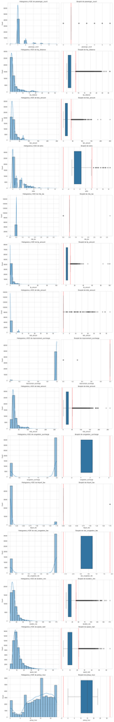

```
--- passenger_count ---
Q1: 1.0
Q3: 1.0
IQR: 0.0
Lower bound: 1.0
Upper bound: 1.0
Número de outliers: 8243

--- trip_distance ---
Q1: 1.1
Q3: 3.7
IQR: 2.6
Lower bound: -2.8
Upper bound: 7.6
Número de outliers: 5991

--- fare_amount ---
Q1: 9.3
Q3: 22.6
IQR: 13.3
Lower bound: -10.65
Upper bound: 42.55
Número de outliers: 4241

--- extra ---
Q1: 0.0
Q3: 2.5
IQR: 2.5
Lower bound: -3.75
Upper bound: 6.25
Número de outliers: 643

--- mta_tax ---
Q1: 0.5
Q3: 0.5
IQR: 0.0
Lower bound: 0.5
Upper bound: 0.5
Número de outliers: 363

```

[output cut: 64 more lines]

```
--- speed_mph ---
Q1: 7.05
Q3: 13.05
IQR: 6.01
Lower bound: -1.97
Upper bound: 22.07
Número de outliers: 3352

--- pickup_hour ---
Q1: 10.0
Q3: 19.0
IQR: 9.0
Lower bound: -3.5
Upper bound: 32.5
Número de outliers: 0
```

```python
plot_combined_graphs(df_clean, features_num, bins=20);
```

*Conclusiones*:

#### **Outliers: impacto potencial**

Analizando el impacto potencial de los outliers del dataset podemos clarificar varios aspectos:

- En cuanto al análisis:
  - Hay muchos "outliers", sin embargo, no son errores, son eventos inusuales pero reales, por ejemplo:
    - Viajes largos.
    - Tarifas altas.
    - Propinas grandes.
    - Peajes puntuales.
    - Trayectos al aeropuerto...
  - Estos "outliers" son muy típicos en datos de movilidad y precios: sesgos
- En cuanto a un modelo predictivo: Sí puede afectar ya que puede "aprender" erróneamente de los datos. Para ello existen varias técnicas para minimizarlos como:
  - Normalizar, escalar o realizar una transformación logarítmica.

En conclusión, los **outliers no invalidan el análisis, pero sí deben ser tratados para una regresión lineal** ya que es sensible a ellos.

### 8. **Primera comparación entre variables**

#### **Diferencias en el importe medio de viaje según el tipo de pago**

```python
df_clean.groupby('payment_type')['total_amount'].mean()
```

```
payment_type
Disputa                      29.623070
Efectivo                     24.445049
Sin cargo                    24.678701
Tarjeta de crédito           29.548272
Viaje con tarifa flexible    25.161442
Name: total_amount, dtype: float64
```

*Observaciones*

Se observan diferencias en el importe medio del viaje (`total_amount`) según el tipo de pago (`payment_type`).  
Los pagos con **tarjeta de crédito** presentan **valores medios más elevados**, lo cual puede explicarse por el registro automático de propinas en este tipo de transacciones, a diferencia del pago en efectivo.  
Asimismo, los viajes en **disputa** muestran importes **medios superiores**, lo que podría estar asociado a **trayectos de mayor coste**.  
Estas diferencias sugieren que el tipo de pago puede aportar información relevante en un futuro modelado.

#### **Diferencias de la distancia edia del viaje por hora**

```python
df_clean.groupby('pickup_hour')['trip_distance'].mean()
```

```
pickup_hour
0     4.167755
1     3.622195
2     3.477155
3     3.852565
4     5.242957
5     5.823162
6     5.259519
7     3.974545
8     3.368811
9     3.207317
10    3.016570
11    3.072732
12    3.436882
13    3.244294
14    3.500252
15    3.544728
16    3.368908
17    3.075078
18    2.927079
19    3.145939
20    3.366086
21    3.443020
22    3.645020
23    4.209628
Name: trip_distance, dtype: float64
```

El análisis de la distancia media del viaje (`trip_distance`) según la hora de recogida (`pickup_hour`) muestra variaciones a lo largo del día.  
Se observan **mayores distancias medias durante la madrugada**, posiblemente asociadas a desplazamientos largos o viajes al aeropuerto, mientras que en **horario diurno** predominan **trayectos más cortos**, característicos de la movilidad urbana.  
Este patrón temporal sugiere que la hora del viaje puede tener capacidad explicativa en un modelo predictivo.

#### **Varianza del precio según duración del viaje**

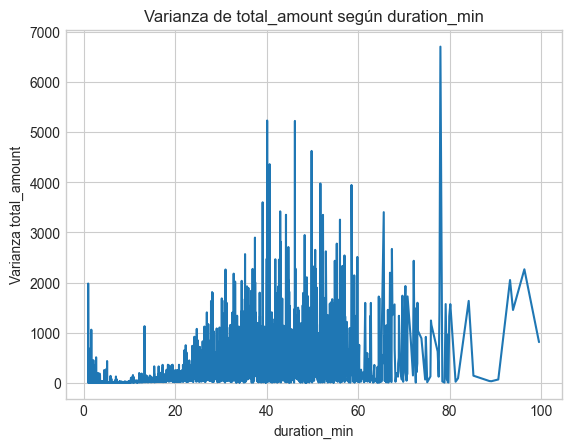

```python
var_graph(df_clean, ['duration_min', 'total_amount'])
```

*Observaciones*:

Se puede observar en la gráfica que la varianza del precio aumenta con la duración.

Esto puede reflejar que:

- En viajes cortos los precios son bastante estables (poca dispersión)
- En viajes largos los precios son muy variables

Se ve picos enormes de varianza, sobre todo, entre 35–60 min y cerca de 75 min

La zona final muy ruidosa (80–100 min), probablemente hay muy pocas muestras.

### 9. **Conclusiones**

Tras el análisis exploratorio, el dataset presenta una calidad global adecuada para el modelado, sin evidencias significativas de errores sistemáticos. Los valores nulos detectados responden principalmente a patrones estructurales y han sido tratados mediante imputación basada en reglas de negocio.

No obstante, se identifican ciertas características que sugieren la necesidad de transformaciones adicionales antes del modelado. En particular, varias variables numéricas presentan asimetría positiva y presencia de valores extremos, lo que podría afectar a modelos lineales.

En consecuencia, el dataset se considera preparado para una fase de modelado preliminar, aunque será recomendable realiza previamente transformaciones como estandarización, análisis de colinealidad y, en algunos casos, transformaciones logarítmicas.

## PARTE 2: Inferencia y Modelado (Dataset Propio)

**Objetivo:** Descubrir relaciones entre variables y predecir resultados.

**Requisitos:**

1. **Análisis de Correlación:** Genera una matriz de correlación y visualízala con un Heatmap. ¿Qué variables están más relacionadas con tu Target?
2. **Relaciones Bivariantes:** Crea Scatter Plots para visualizar la relación entre las variables independientes más fuertes y tu variable objetivo.
3. **Regresión Lineal (Scikit-Learn):**
   - Selecciona tus variables predictoras ($X$) y tu objetivo ($y$).
   - Realiza un Train/Test Split (80/20).
   - Entrena un modelo de Regresión Lineal.
   - Evalúa el modelo usando **R²** y **RMSE**.
4. **Regresión logistica:**
   - Selecciona tus variables predictoras ($X$) y tu objetivo ($y$).
   - Realiza un Train/Test Split (80/20).
   - Entrena un modelo de Regresión Lineal.
   - Evalúa el modelo usando **R²** y **RMSE**.

**📝 Conclusión:** ¿Es tu modelo capaz de predecir con precisión? ¿Qué variables son las más influyentes?¿Qué tipo de regresión es la más apropiada?

Amplía el análisis incorporando los siguientes aspectos:

- **Diagnóstico del modelo de regresión lineal** Analiza los residuos del modelo entrenado:
  - Distribución de los residuos
  - Relación entre residuos y valores predichos  
    Comenta si se cumplen los supuestos básicos del modelo.
- **Regresión logística: adecuación del modelo** Justifica si la regresión logística es apropiada para tu variable objetivo y discute las diferencias conceptuales con la regresión lineal.
- **Comparación de modelos** Compara brevemente el rendimiento y la idoneidad de ambos enfoques (lineal vs. logístico) más allá de las métricas numéricas.

```python
# TU CÓDIGO AQUÍ - PARTE 2
from sklearn.linear_model import LinearRegression, LogisticRegression
from sklearn.model_selection import train_test_split
from sklearn.metrics import mean_squared_error, r2_score, classification_report
from sklearn.preprocessing import StandardScaler, OneHotEncoder

# Scripts creados para la optimización
from utils.graphs_pipeline import corr_num, grafico_dispersion_con_correlacion, plot_categorical_numerical_relationship, distribucion_categorica_relativa
```

### 1. **Análisis de Correlación**

En primer lugar, seleccionaré la variable objetivo (Target) y será `total_amount`, ya que representa el importe total pagado por el cliente y permite modelar el coste final del viaje.

```python
target = 'total_amount'
```

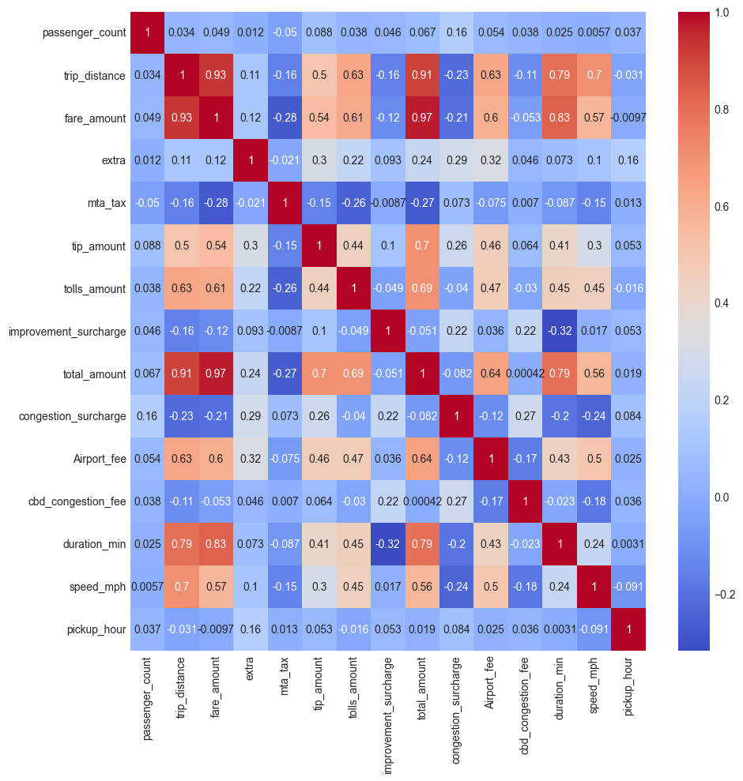

```python
# Matriz de correlación y heatmap de las variables numéricas
var_corr, matriz_corr = corr_num(df_clean, features_num)
```

```python
# Variables que tienen correlación con el Target tanto positiva como negativa
var_corr
```

```
['trip_distance',
 'fare_amount',
 'tip_amount',
 'tolls_amount',
 'Airport_fee',
 'duration_min',
 'speed_mph']
```

```python
# Matriz de correlación
matriz_corr
```

|  | passenger_count | trip_distance | fare_amount | extra | mta_tax | tip_amount | tolls_amount | improvement_surcharge | total_amount | congestion_surcharge | Airport_fee | cbd_congestion_fee | duration_min | speed_mph | pickup_hour |
| --- | --- | --- | --- | --- | --- | --- | --- | --- | --- | --- | --- | --- | --- | --- | --- |
| passenger_count | 1.000000 | 0.033829 | 0.048847 | 0.011886 | -0.049805 | 0.087702 | 0.037521 | 0.046493 | 0.066839 | 0.156220 | 0.054328 | 0.038067 | 0.024946 | 0.005727 | 0.037049 |
| trip_distance | 0.033829 | 1.000000 | 0.929317 | 0.114286 | -0.157324 | 0.500140 | 0.625086 | -0.155548 | 0.907081 | -0.226024 | 0.626286 | -0.114655 | 0.789028 | 0.704110 | -0.030914 |
| fare_amount | 0.048847 | 0.929317 | 1.000000 | 0.116922 | -0.275280 | 0.542731 | 0.613630 | -0.119259 | 0.970061 | -0.206338 | 0.595704 | -0.053490 | 0.831558 | 0.569427 | -0.009705 |
| extra | 0.011886 | 0.114286 | 0.116922 | 1.000000 | -0.021007 | 0.304172 | 0.216820 | 0.093466 | 0.235249 | 0.287880 | 0.319099 | 0.046427 | 0.073182 | 0.103533 | 0.164338 |
| mta_tax | -0.049805 | -0.157324 | -0.275280 | -0.021007 | 1.000000 | -0.154048 | -0.255834 | -0.008680 | -0.270043 | 0.072967 | -0.075344 | 0.007049 | -0.086965 | -0.147240 | 0.013146 |
| tip_amount | 0.087702 | 0.500140 | 0.542731 | 0.304172 | -0.154048 | 1.000000 | 0.442186 | 0.104996 | 0.700111 | 0.259543 | 0.458455 | 0.063751 | 0.410722 | 0.297790 | 0.052647 |
| tolls_amount | 0.037521 | 0.625086 | 0.613630 | 0.216820 | -0.255834 | 0.442186 | 1.000000 | -0.048841 | 0.693973 | -0.040212 | 0.466682 | -0.030270 | 0.451391 | 0.446484 | -0.016208 |
| improvement_surcharge | 0.046493 | -0.155548 | -0.119259 | 0.093466 | -0.008680 | 0.104996 | -0.048841 | 1.000000 | -0.051020 | 0.223008 | 0.036312 | 0.217804 | -0.319062 | 0.016769 | 0.052914 |
| total_amount | 0.066839 | 0.907081 | 0.970061 | 0.235249 | -0.270043 | 0.700111 | 0.693973 | -0.051020 | 1.000000 | -0.081524 | 0.642918 | 0.000421 | 0.789612 | 0.562554 | 0.019126 |
| congestion_surcharge | 0.156220 | -0.226024 | -0.206338 | 0.287880 | 0.072967 | 0.259543 | -0.040212 | 0.223008 | -0.081524 | 1.000000 | -0.117446 | 0.266883 | -0.195104 | -0.238163 | 0.084438 |
| Airport_fee | 0.054328 | 0.626286 | 0.595704 | 0.319099 | -0.075344 | 0.458455 | 0.466682 | 0.036312 | 0.642918 | -0.117446 | 1.000000 | -0.166054 | 0.428664 | 0.498766 | 0.025277 |
| cbd_congestion_fee | 0.038067 | -0.114655 | -0.053490 | 0.046427 | 0.007049 | 0.063751 | -0.030270 | 0.217804 | 0.000421 | 0.266883 | -0.166054 | 1.000000 | -0.023439 | -0.184509 | 0.036089 |
| duration_min | 0.024946 | 0.789028 | 0.831558 | 0.073182 | -0.086965 | 0.410722 | 0.451391 | -0.319062 | 0.789612 | -0.195104 | 0.428664 | -0.023439 | 1.000000 | 0.236846 | 0.003128 |
| speed_mph | 0.005727 | 0.704110 | 0.569427 | 0.103533 | -0.147240 | 0.297790 | 0.446484 | 0.016769 | 0.562554 | -0.238163 | 0.498766 | -0.184509 | 0.236846 | 1.000000 | -0.091338 |
| pickup_hour | 0.037049 | -0.030914 | -0.009705 | 0.164338 | 0.013146 | 0.052647 | -0.016208 | 0.052914 | 0.019126 | 0.084438 | 0.025277 | 0.036089 | 0.003128 | -0.091338 | 1.000000 |

En la función anterior se ha filtrado aquellas variables que tengan con el Target una correlación entre 1 y 0.5, -1 y -0.5 Este tipo de correlación (Pearson) funciona muy bien si la relación es lineal.

En el apartado 2. visualizaremos las gráficas contra el Target y sus supuestas variables dependientes.

### 2. **Relaciones Bivariantes**

#### **Variables numéricas VS Target**

Con nuestra matriz de correlación creada anteriormente, vamos a ver aquellas variables independientes más fuertes y las relacionaremos con un **Scatter Plot** contra el Target

```python
var_corr
```

```
['trip_distance',
 'fare_amount',
 'tip_amount',
 'tolls_amount',
 'Airport_fee',
 'duration_min',
 'speed_mph']
```

Filtrando por aquellas que correlacionan con el Target:

- `trip_distance` y `fare_amount` tienen una correlación de 0.93, y la que más correla con el Target es `fare_amount` con un 0.97.
- `fare_amount` y `duration_min` tienen un correlación de 0.83 y la que más correla con el Target es `fare_amount`.

```python
scatter = ['fare_amount', 'tip_amount', 'tolls_amount', 'Airport_fee', 'speed_mph']
```

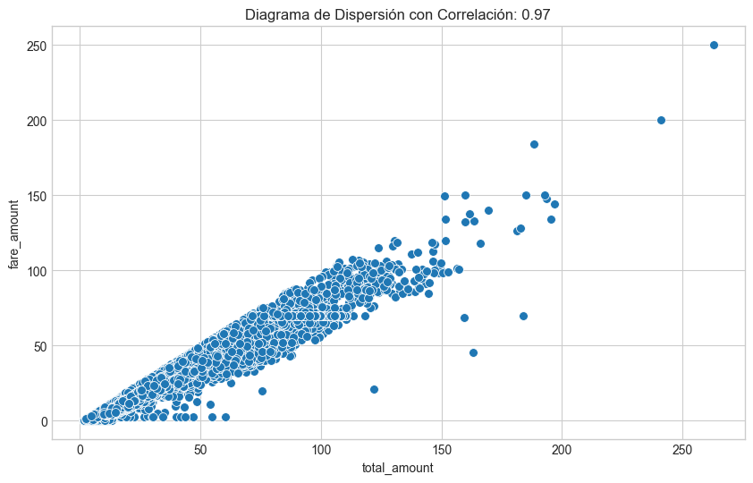

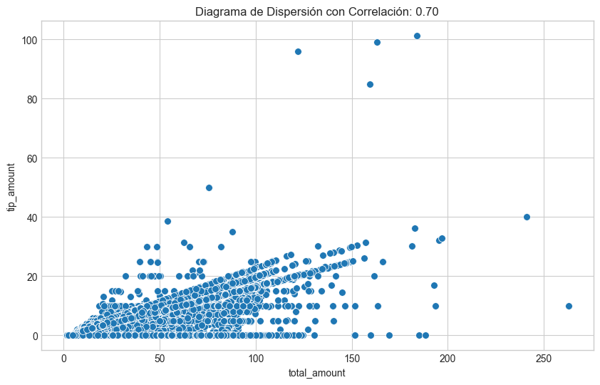

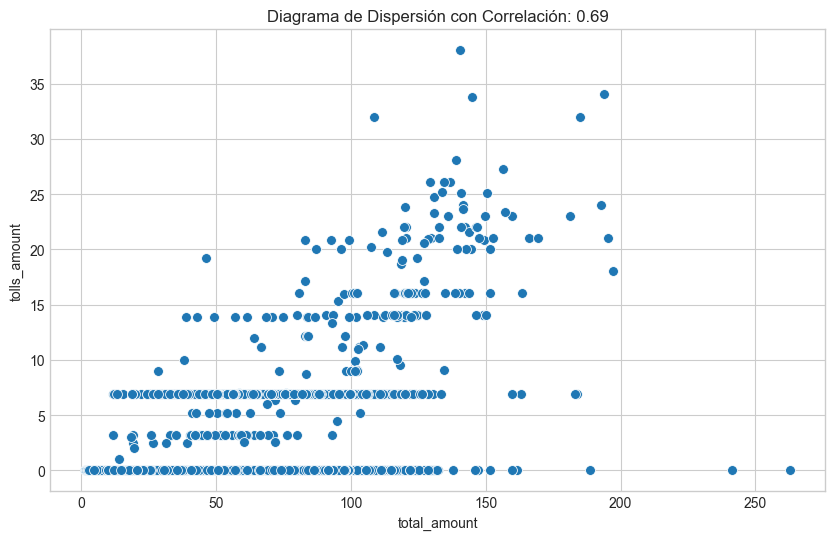

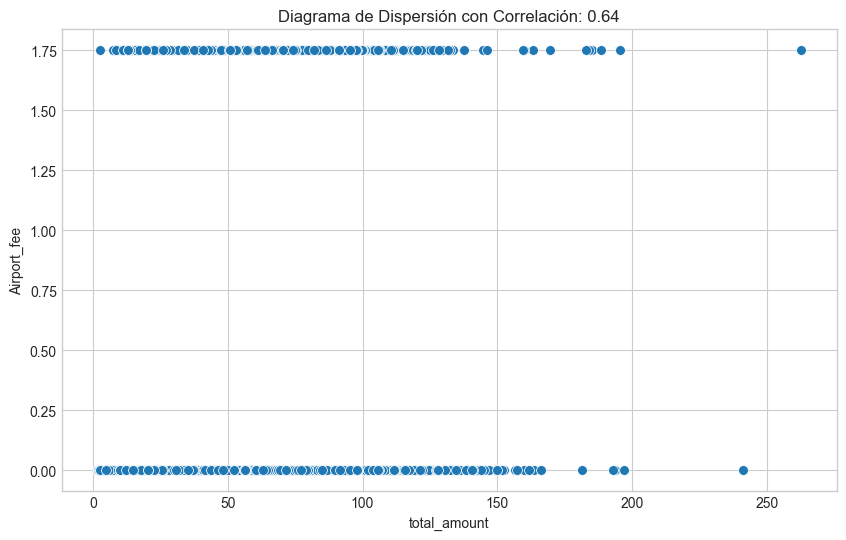

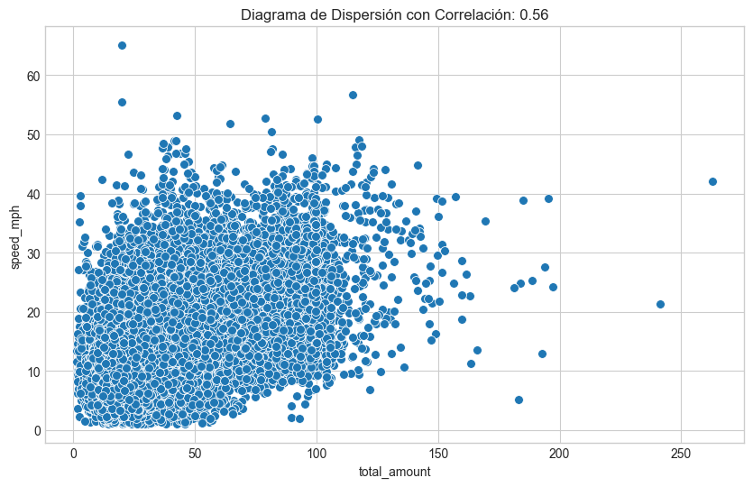

```python
for col in scatter:
    grafico_dispersion_con_correlacion(df_clean, target, col, tamano_puntos=50, mostrar_correlacion=True)
```

*Observaciones*:

- La mayoría si se puede apreciar que tienen una relación lineal con un poco de dispersión en alguna de ellas, sin embargo, `Airport_fee` tiene una correlación de 0.64 y no se visualiza una relación con el Target, por lo tanto, esta variable la eliminamos de las variables correlacionadas.

```python
for idx, var in enumerate(var_corr):
    if var == 'Airport_fee':
        var_corr.pop(idx)

var_corr
```

```
['trip_distance',
 'fare_amount',
 'tip_amount',
 'tolls_amount',
 'duration_min',
 'speed_mph']
```

```python
for idx, var in enumerate(scatter):
    if var == 'Airport_fee':
        var_corr.pop(idx)

features_num_lr = scatter # Selecciono estas para hacer mi modelado después
features_num_lr
```

```
['fare_amount', 'tip_amount', 'tolls_amount', 'Airport_fee', 'speed_mph']
```

#### **Variables categóricas VS Target**

```python
features_cat
```

```
['store_and_fwd_flag',
 'payment_type',
 'day_of_week',
 'PU_city',
 'PU_Borough',
 'DO_city',
 'DO_Borough',
 'provider',
 'tariff_type']
```

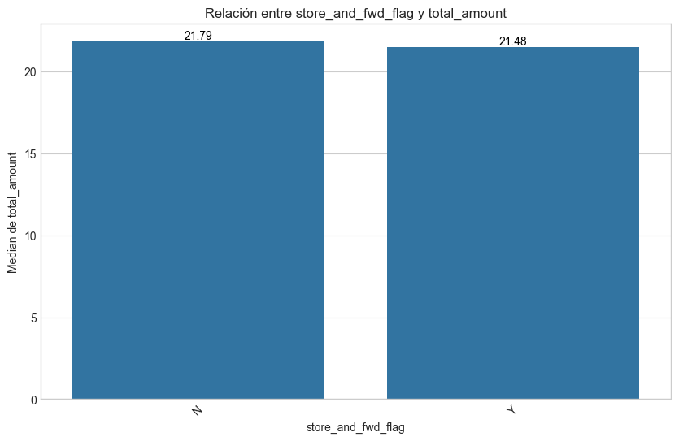

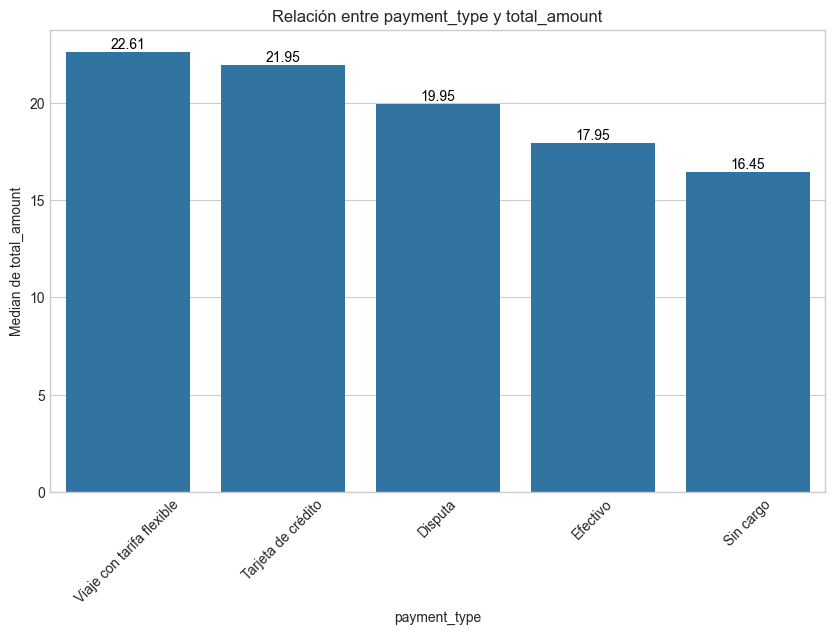

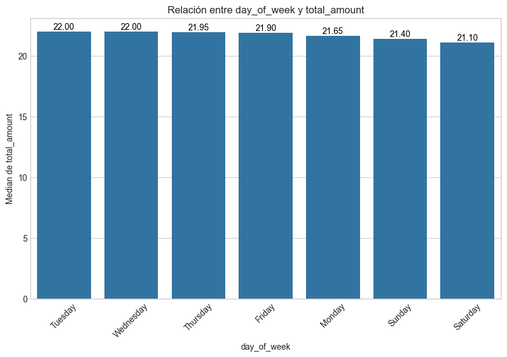

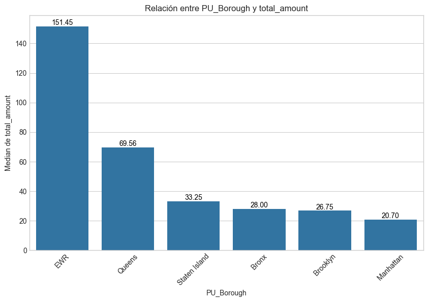

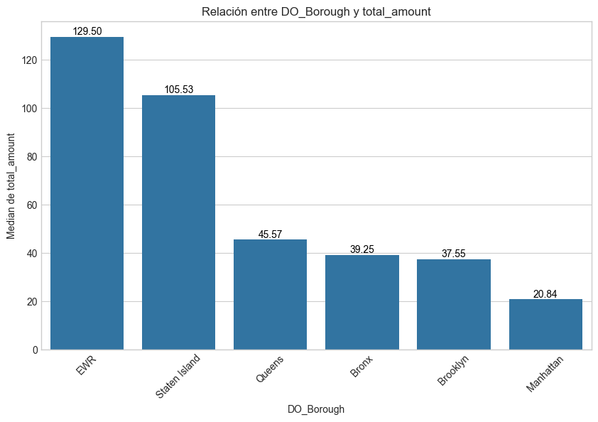

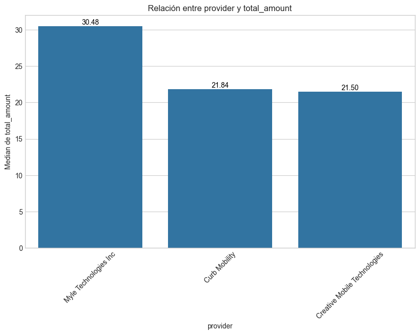

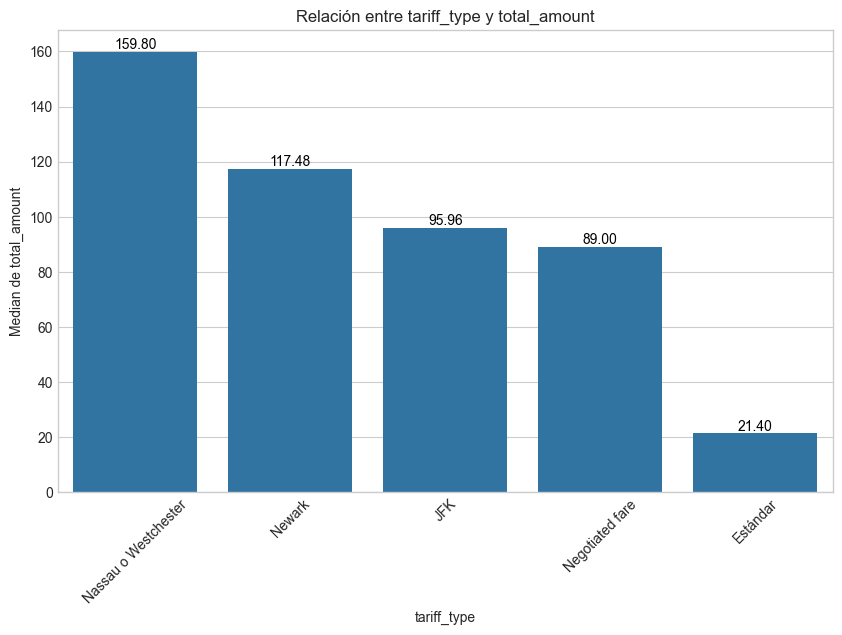

```python
for col in features_cat:
    if col not in ['PU_city', 'DO_city']: # No visualizamos estas variables ya que tienen muchas categorías
        plot_categorical_numerical_relationship(df_clean, col, target, show_values=True, measure='median')
```

*Observaciones*:

- Voy a considerar, analizando las gráficas anteriores, aquellas variables que sí pueden tener una relación con el Target, ya que se una diferencia clara entre categorías:
  - `payment_type`
  - `provider`
  - `tariff_type`
  - `PU_Borough`
  - `DO_Borough`

```python
features_cat_lr = ['payment_type', 'provider', 'tariff_type', 'PU_Borough', 'DO_Borough']
```

### 3. **Regresión Lineal (Scikit-Learn)**

```python
df_final = df_clean[features_num_lr + features_cat_lr + [target]]
```

```python
df_final
```

|  | fare_amount | tip_amount | tolls_amount | Airport_fee | speed_mph | payment_type | provider | tariff_type | PU_Borough | DO_Borough | total_amount |
| --- | --- | --- | --- | --- | --- | --- | --- | --- | --- | --- | --- |
| 0 | 45.00 | 14.78 | 0.00 | 0.00 | 8.896118 | Tarjeta de crédito | Curb Mobility | Negotiated fare | Manhattan | Brooklyn | 64.03 |
| 1 | 9.30 | 2.37 | 0.00 | 0.00 | 10.008000 | Tarjeta de crédito | Curb Mobility | Estándar | Manhattan | Manhattan | 18.17 |
| 2 | 7.20 | 2.00 | 0.00 | 0.00 | 7.379501 | Tarjeta de crédito | Curb Mobility | Estándar | Manhattan | Manhattan | 16.45 |
| 3 | 33.10 | 5.00 | 6.94 | 0.00 | 17.154047 | Tarjeta de crédito | Curb Mobility | Estándar | Manhattan | Brooklyn | 50.79 |
| 4 | 7.20 | 0.00 | 0.00 | 0.00 | 7.075145 | Tarjeta de crédito | Curb Mobility | Estándar | Manhattan | Manhattan | 12.95 |
| ... | ... | ... | ... | ... | ... | ... | ... | ... | ... | ... | ... |
| 49995 | 70.99 | 0.00 | 6.94 | 1.75 | 17.891269 | Viaje con tarifa flexible | Creative Mobile Technologies | Estándar | Manhattan | Queens | 81.93 |
| 49996 | 11.40 | 3.43 | 0.00 | 0.00 | 8.457143 | Tarjeta de crédito | Curb Mobility | Estándar | Manhattan | Manhattan | 20.58 |
| 49997 | 24.70 | 5.89 | 0.00 | 0.00 | 9.813630 | Tarjeta de crédito | Curb Mobility | Estándar | Manhattan | Manhattan | 35.34 |
| 49998 | 40.10 | 0.00 | 0.00 | 1.75 | 13.022260 | Efectivo | Curb Mobility | Estándar | Queens | Queens | 50.85 |
| 49999 | 5.80 | 2.46 | 0.00 | 0.00 | 19.277419 | Tarjeta de crédito | Curb Mobility | Estándar | Manhattan | Manhattan | 14.76 |

50000 rows × 11 columns

```python
# Realizo un Train/Test Split (80/20).
train_set, test_set = train_test_split(df_final, test_size = 0.20, random_state = 42)
```

Antes de entrenar mi modelo voy a escalar y normalizar las variables numéricasy a estandarizar las variables categóricas ya que la Regresión Lineal es muy sensible al escalado.

#### **Transformación previa al modelado**

##### *Variables numéricas*

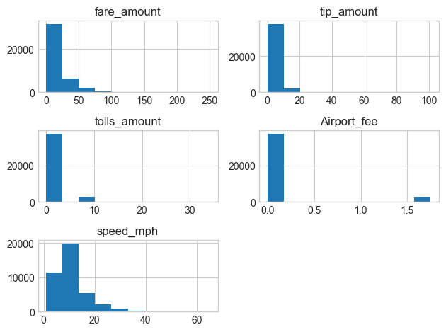

```python
# Visualización de la distribución de las numéricas
train_set[features_num_lr].hist()
plt.tight_layout()
```

```python
# Normalizamos con transformación logarítmica
for col in features_num_lr:
    desplaza = 0
    if train_set[col].min() <= 0: # En las features que tengan valores 0
        desplaza = int(abs(train_set[col].min())) + 1
    train_set[col] = np.log(train_set[col] + desplaza)
    test_set[col] = np.log(test_set[col] + desplaza)
```

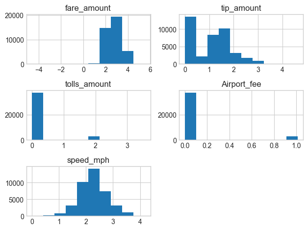

```python
train_set[features_num_lr].hist() # Un poco mejor
plt.tight_layout()
```

```python
scaler = StandardScaler()

train_set[features_num_lr] = scaler.fit_transform(train_set[features_num_lr])
test_set[features_num_lr] = scaler.transform(test_set[features_num_lr])
```

```python
train_set[features_num_lr].describe() # Estandarizamos con media cercana a 0 y desviación a 1
```

|  | fare_amount | tip_amount | tolls_amount | Airport_fee | speed_mph |
| --- | --- | --- | --- | --- | --- |
| count | 4.000000e+04 | 4.000000e+04 | 4.000000e+04 | 4.000000e+04 | 4.000000e+04 |
| mean | -7.673862e-17 | 1.137757e-16 | 7.975842e-17 | 2.269296e-17 | 4.742873e-17 |
| std | 1.000013e+00 | 1.000013e+00 | 1.000013e+00 | 1.000013e+00 | 1.000013e+00 |
| min | -1.059297e+01 | -1.221701e+00 | -2.727665e-01 | -2.761910e-01 | -4.457803e+00 |
| 25% | -7.065723e-01 | -1.221701e+00 | -2.727665e-01 | -2.761910e-01 | -6.285982e-01 |
| 50% | -9.441686e-02 | 2.327817e-01 | -2.727665e-01 | -2.761910e-01 | -4.482315e-02 |
| 75% | 5.777356e-01 | 6.849286e-01 | -2.727665e-01 | -2.761910e-01 | 5.834608e-01 |
| max | 4.054169e+00 | 4.212330e+00 | 6.343857e+00 | 3.620683e+00 | 3.735162e+00 |

##### *Variables categóricas*

Como no tenemos ninguna variable ordinal, aplicaremos el One Hot Encoder para codificar las categorías por números.

```python
onehot = OneHotEncoder()
train_cat_sparse = onehot.fit_transform(train_set[features_cat_lr])
test_cat_sparse = onehot.transform(test_set[features_cat_lr])
```

```python
train_cat_encoded = pd.DataFrame(
    train_cat_sparse.toarray(),
    columns=onehot.get_feature_names_out(features_cat_lr),
    index=train_set.index
)

test_cat_encoded = pd.DataFrame(
    test_cat_sparse.toarray(),
    columns=onehot.get_feature_names_out(features_cat_lr),
    index=test_set.index
)

X_train_p = train_set.drop(columns=features_cat_lr).join(train_cat_encoded)
X_test_p = test_set.drop(columns=features_cat_lr).join(test_cat_encoded)
```

```python
X_train_p
```

|  | fare_amount | tip_amount | tolls_amount | Airport_fee | speed_mph | total_amount | payment_type_Disputa | payment_type_Efectivo | payment_type_Sin cargo | payment_type_Tarjeta de crédito | ... | PU_Borough_EWR | PU_Borough_Manhattan | PU_Borough_Queens | PU_Borough_Staten Island | DO_Borough_Bronx | DO_Borough_Brooklyn | DO_Borough_EWR | DO_Borough_Manhattan | DO_Borough_Queens | DO_Borough_Staten Island |
| --- | --- | --- | --- | --- | --- | --- | --- | --- | --- | --- | --- | --- | --- | --- | --- | --- | --- | --- | --- | --- | --- |
| 39087 | -0.325893 | 0.894425 | -0.272767 | -0.276191 | -1.144468 | 21.91 | 0.0 | 0.0 | 0.0 | 1.0 | ... | 0.0 | 1.0 | 0.0 | 0.0 | 0.0 | 0.0 | 0.0 | 1.0 | 0.0 | 0.0 |
| 30893 | -0.325893 | 0.632825 | -0.272767 | -0.276191 | 0.014385 | 23.20 | 0.0 | 0.0 | 0.0 | 1.0 | ... | 0.0 | 1.0 | 0.0 | 0.0 | 0.0 | 0.0 | 0.0 | 1.0 | 0.0 | 0.0 |
| 45278 | 0.386424 | 0.682610 | -0.272767 | -0.276191 | -0.156547 | 31.11 | 0.0 | 0.0 | 0.0 | 1.0 | ... | 0.0 | 1.0 | 0.0 | 0.0 | 0.0 | 0.0 | 0.0 | 1.0 | 0.0 | 0.0 |
| 16398 | -0.942554 | -1.221701 | -0.272767 | -0.276191 | -0.116101 | 13.65 | 0.0 | 1.0 | 0.0 | 0.0 | ... | 0.0 | 1.0 | 0.0 | 0.0 | 0.0 | 0.0 | 0.0 | 1.0 | 0.0 | 0.0 |
| 13653 | -0.157925 | -1.221701 | -0.272767 | -0.276191 | 0.606551 | 15.09 | 0.0 | 0.0 | 0.0 | 0.0 | ... | 0.0 | 0.0 | 0.0 | 0.0 | 0.0 | 1.0 | 0.0 | 0.0 | 0.0 | 0.0 |
| ... | ... | ... | ... | ... | ... | ... | ... | ... | ... | ... | ... | ... | ... | ... | ... | ... | ... | ... | ... | ... | ... |
| 11284 | 0.022923 | -1.221701 | -0.272767 | -0.276191 | -0.152860 | 20.15 | 0.0 | 0.0 | 0.0 | 0.0 | ... | 0.0 | 1.0 | 0.0 | 0.0 | 0.0 | 0.0 | 0.0 | 1.0 | 0.0 | 0.0 |
| 44732 | -0.244548 | -1.221701 | -0.272767 | -0.276191 | -0.771318 | 18.55 | 0.0 | 1.0 | 0.0 | 0.0 | ... | 0.0 | 1.0 | 0.0 | 0.0 | 0.0 | 0.0 | 0.0 | 1.0 | 0.0 | 0.0 |
| 38158 | 0.706253 | 1.272321 | -0.272767 | -0.276191 | 0.149918 | 36.81 | 0.0 | 0.0 | 0.0 | 1.0 | ... | 0.0 | 1.0 | 0.0 | 0.0 | 0.0 | 0.0 | 0.0 | 1.0 | 0.0 | 0.0 |
| 860 | -1.076754 | 0.212176 | -0.272767 | -0.276191 | 0.322566 | 14.34 | 0.0 | 0.0 | 0.0 | 1.0 | ... | 0.0 | 1.0 | 0.0 | 0.0 | 0.0 | 0.0 | 0.0 | 1.0 | 0.0 | 0.0 |
| 15795 | 0.165893 | 0.965857 | -0.272767 | -0.276191 | -0.644615 | 27.19 | 0.0 | 0.0 | 0.0 | 1.0 | ... | 0.0 | 1.0 | 0.0 | 0.0 | 0.0 | 0.0 | 0.0 | 1.0 | 0.0 | 0.0 |

40000 rows × 31 columns

#### **Modelado**

```python
# Selecciono mis variables predictoras (X) y tu objetivo (y).
X_train = X_train_p.drop(target, axis=1)
y_train = X_train_p[target]
X_test = X_test_p.drop(target, axis=1)
y_test = X_test_p[target]
```

```python
# Entreno un modelo de Regresión Lineal.
lr = LinearRegression(n_jobs=-1)
lr.fit(X_train, y_train)
```

```
LinearRegression(n_jobs=-1)
```

```python
y_pred_train = lr.predict(X_train)

mse = mean_squared_error(y_train, y_pred_train)
r2 = r2_score(y_train, y_pred_train)
print('RMSE train:', round(np.sqrt(mse), 2))
print('r^2 train:', round(r2, 2))
```

```
RMSE train: 5.46
r^2 train: 0.93
```

```python
# Evalúo el modelo usando **R²** y **RMSE**
y_pred = lr.predict(X_test)
mse = mean_squared_error(y_test, y_pred)
r2 = r2_score(y_test, y_pred)
print('RMSE test:', round(np.sqrt(mse), 2))
print('r^2 test:', round(r2, 2))
```

```
RMSE test: 5.23
r^2 test: 0.93
```

*Observaciones*:

- El modelo explica el 93 % de la varianza del precio
- El error medio es 5€ por viaje

Parece que está prediciendo bastante bien, sin embargo, vamos a ver la ditribición de los residuos.

#### **Diagnóstico del modelo de regresión lineal**

Analiza los residuos del modelo entrenado:

- Distribución de los residuos
- Relación entre residuos y valores predichos  
  Comenta si se cumplen los supuestos básicos del modelo.

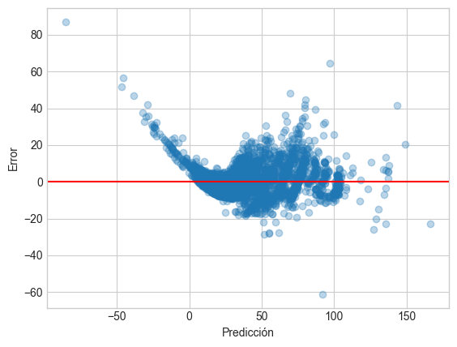

```python
residuals = y_test - y_pred

plt.scatter(y_pred, residuals, alpha=0.3)
plt.axhline(0, color="red")
plt.xlabel("Predicción")
plt.ylabel("Error")
plt.show()
```

El gráfico de residuos muestra cierta curvatura, indicando que la relación entre las variables predictoras y el precio no es completamente lineal. No obstante, el modelo presenta un buen ajuste global, siendo capaz de capturar la mayor parte de la variabilidad del precio del viaje.

### 4. **Regresión logística: adecuación del modelo**

Para utilizar un modelo de Regresión Logística, la variable objetivo deberia ser una variable categórica, no una numérica por lo que no se podría seguir los mismos criterios para la Regresión Lineal realizada en el punto anterior.

```python
df_clean['tariff_type'].value_counts()
```

```
tariff_type
Estándar                48230
JFK                      1420
Negotiated fare           211
Newark                    128
Nassau o Westchester       11
Name: count, dtype: int64
```

Utilizaremos como Target predecir el tipo de tarifa según el viaje que se va a realizar

```python
target = 'tariff_type'
```

Lo más idóneo sería realizar un análisis acorde a esta target como hemos realizado anteriormente. En este caso, haremos uso de todas la features

```python
len(df_clean.columns)
```

```
25
```

```python
# Selecciono features
features_num_lgr = [col for col in df_clean.columns if df_clean[col].dtype in ['int', 'float'] ]
features_cat_lgr = [col for col in df_clean.columns if col not in features_num_lgr and col not in [target, 'tpep_pickup_datetime']]
```

```python
# Compruebo que están todas menos el target
len(features_num_lgr) + len(features_cat_lgr)
```

```
23
```

```python
# Realizo un Train/Test Split (80/20).
train_set, test_set = train_test_split(df_clean, test_size = 0.20, random_state = 42)
```

#### **Transformación previa al modelado**

##### *Variables numéricas*

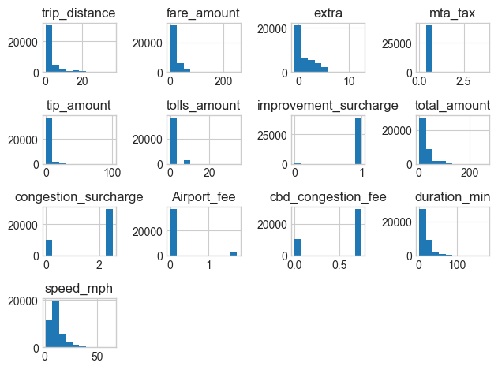

```python
# Visualización de la distribución de las numéricas
train_set[features_num_lgr].hist()
plt.tight_layout()
```

```python
# Normalizamos con transformación logarítmica
for col in features_num_lgr:
    desplaza = 0
    if train_set[col].min() <= 0: # En las features que tengan valores 0
        desplaza = int(abs(train_set[col].min())) + 1
    train_set[col] = np.log(train_set[col] + desplaza)
    test_set[col] = np.log(test_set[col] + desplaza)
```

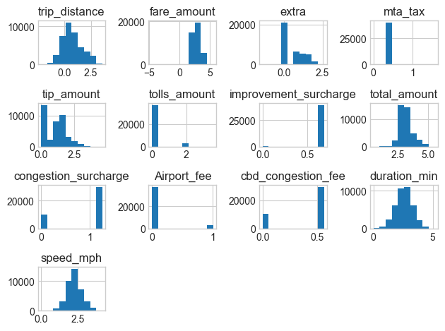

```python
train_set[features_num_lgr].hist() # Un poco mejor
plt.tight_layout()
```

```python
scaler = StandardScaler()

train_set[features_num_lgr] = scaler.fit_transform(train_set[features_num_lgr])
test_set[features_num_lgr] = scaler.transform(test_set[features_num_lgr])
```

```python
train_set[features_num_lgr].describe() # Estandarizamos con media cercana a 0 y desviación a 1
```

|  | trip_distance | fare_amount | extra | mta_tax | tip_amount | tolls_amount | improvement_surcharge | total_amount | congestion_surcharge | Airport_fee | cbd_congestion_fee | duration_min | speed_mph |
| --- | --- | --- | --- | --- | --- | --- | --- | --- | --- | --- | --- | --- | --- |
| count | 4.000000e+04 | 4.000000e+04 | 4.000000e+04 | 4.000000e+04 | 4.000000e+04 | 4.000000e+04 | 4.000000e+04 | 4.000000e+04 | 4.000000e+04 | 4.000000e+04 | 4.000000e+04 | 4.000000e+04 | 4.000000e+04 |
| mean | 3.055334e-17 | -7.673862e-17 | 9.414691e-18 | -3.421974e-15 | 1.137757e-16 | 7.975842e-17 | -1.219558e-15 | -5.986323e-17 | -1.678657e-17 | 2.269296e-17 | 6.004086e-17 | 3.691270e-16 | 4.742873e-17 |
| std | 1.000013e+00 | 1.000013e+00 | 1.000013e+00 | 1.000013e+00 | 1.000013e+00 | 1.000013e+00 | 1.000013e+00 | 1.000013e+00 | 1.000013e+00 | 1.000013e+00 | 1.000013e+00 | 1.000013e+00 | 1.000013e+00 |
| min | -3.155003e+00 | -1.059297e+01 | -2.890673e+00 | -1.165973e+01 | -1.221701e+00 | -2.727665e-01 | -7.624695e+00 | -5.007453e+00 | -1.702538e+00 | -2.761910e-01 | -1.664020e+00 | -3.611515e+00 | -4.457803e+00 |
| 25% | -7.037230e-01 | -7.065723e-01 | -8.514526e-01 | 8.253555e-02 | -1.221701e+00 | -2.727665e-01 | 1.318024e-01 | -6.650093e-01 | -1.702538e+00 | -2.761910e-01 | -1.664020e+00 | -6.495617e-01 | -6.285982e-01 |
| 50% | -1.331505e-01 | -9.441686e-02 | -8.514526e-01 | 8.253555e-02 | 2.327817e-01 | -2.727665e-01 | 1.318024e-01 | -1.615466e-01 | 5.873584e-01 | -2.761910e-01 | 6.009543e-01 | 1.556892e-02 | -4.482315e-02 |
| 75% | 5.876333e-01 | 5.777356e-01 | 9.913444e-01 | 8.253555e-02 | 6.849286e-01 | -2.727665e-01 | 1.318024e-01 | 4.731352e-01 | 5.873584e-01 | -2.761910e-01 | 6.009543e-01 | 6.614719e-01 | 5.834608e-01 |
| max | 3.021508e+00 | 4.054169e+00 | 2.977068e+00 | 3.346413e+01 | 4.212330e+00 | 6.343857e+00 | 1.318024e-01 | 4.420360e+00 | 5.873584e-01 | 3.620683e+00 | 6.009543e-01 | 3.637903e+00 | 3.735162e+00 |

##### *Variables categóricas*

Como no tenemos ninguna variable ordinal, aplicaremos el One Hot Encoder para codificar las categorías por números.

```python
onehot = OneHotEncoder(handle_unknown='ignore')
train_cat_sparse = onehot.fit_transform(train_set[features_cat_lgr])
test_cat_sparse = onehot.transform(test_set[features_cat_lgr])
```

```python
train_cat_encoded = pd.DataFrame(
    train_cat_sparse.toarray(),
    columns=onehot.get_feature_names_out(features_cat_lgr),
    index=train_set.index
)

test_cat_encoded = pd.DataFrame(
    test_cat_sparse.toarray(),
    columns=onehot.get_feature_names_out(features_cat_lgr),
    index=test_set.index
)

X_train_p = train_set.drop(columns=features_cat_lgr).join(train_cat_encoded)
X_test_p = test_set.drop(columns=features_cat_lgr).join(test_cat_encoded)
```

```python
X_train_p
```

|  | tpep_pickup_datetime | trip_distance | fare_amount | extra | mta_tax | tip_amount | tolls_amount | improvement_surcharge | total_amount | congestion_surcharge | ... | DO_city_Yorkville West | DO_Borough_Bronx | DO_Borough_Brooklyn | DO_Borough_EWR | DO_Borough_Manhattan | DO_Borough_Queens | DO_Borough_Staten Island | provider_Creative Mobile Technologies | provider_Curb Mobility | provider_Myle Technologies Inc |
| --- | --- | --- | --- | --- | --- | --- | --- | --- | --- | --- | --- | --- | --- | --- | --- | --- | --- | --- | --- | --- | --- |
| 39087 | 2025-08-14 11:44:34 | -0.684541 | -0.325893 | -0.851453 | 0.082536 | 0.894425 | -0.272767 | 0.131802 | -0.153967 | 0.587358 | ... | 0.0 | 0.0 | 0.0 | 0.0 | 1.0 | 0.0 | 0.0 | 0.0 | 1.0 | 0.0 |
| 30893 | 2025-02-24 16:56:53 | 0.034186 | -0.325893 | 1.957458 | 0.082536 | 0.632825 | -0.272767 | 0.131802 | -0.048627 | 0.587358 | ... | 0.0 | 0.0 | 0.0 | 0.0 | 1.0 | 0.0 | 0.0 | 1.0 | 0.0 | 0.0 |
| 45278 | 2025-03-28 17:58:47 | 0.364370 | 0.386424 | 1.957458 | 0.082536 | 0.682610 | -0.272767 | 0.131802 | 0.491575 | 0.587358 | ... | 0.0 | 0.0 | 0.0 | 0.0 | 1.0 | 0.0 | 0.0 | 1.0 | 0.0 | 0.0 |
| 16398 | 2025-11-10 20:13:11 | -0.893954 | -0.942554 | 0.168157 | 0.082536 | -1.221701 | -0.272767 | 0.131802 | -1.025289 | 0.587358 | ... | 0.0 | 0.0 | 0.0 | 0.0 | 1.0 | 0.0 | 0.0 | 0.0 | 1.0 | 0.0 |
| 13653 | 2025-02-16 05:20:19 | 0.182973 | -0.157925 | -0.851453 | 0.082536 | -1.221701 | -0.272767 | 0.131802 | -0.840617 | -1.702538 | ... | 0.0 | 0.0 | 1.0 | 0.0 | 0.0 | 0.0 | 0.0 | 0.0 | 1.0 | 0.0 |
| ... | ... | ... | ... | ... | ... | ... | ... | ... | ... | ... | ... | ... | ... | ... | ... | ... | ... | ... | ... | ... | ... |
| 11284 | 2025-01-15 19:41:09 | 0.029336 | 0.022923 | -0.851453 | 0.082536 | -1.221701 | -0.272767 | 0.131802 | -0.308158 | -1.702538 | ... | 0.0 | 0.0 | 0.0 | 0.0 | 1.0 | 0.0 | 0.0 | 0.0 | 1.0 | 0.0 |
| 44732 | 2025-05-08 22:53:24 | -0.387829 | -0.244548 | 0.168157 | 0.082536 | -1.221701 | -0.272767 | 0.131802 | -0.460499 | 0.587358 | ... | 0.0 | 0.0 | 0.0 | 0.0 | 1.0 | 0.0 | 0.0 | 0.0 | 1.0 | 0.0 |
| 38158 | 2025-02-08 17:15:12 | 0.691711 | 0.706253 | -0.851453 | 0.082536 | 1.272321 | -0.272767 | 0.131802 | 0.801360 | 0.587358 | ... | 0.0 | 0.0 | 0.0 | 0.0 | 1.0 | 0.0 | 0.0 | 0.0 | 1.0 | 0.0 |
| 860 | 2025-05-29 08:02:27 | -0.784107 | -1.076754 | -0.851453 | 0.082536 | 0.212176 | -0.272767 | 0.131802 | -0.934487 | 0.587358 | ... | 0.0 | 0.0 | 0.0 | 0.0 | 1.0 | 0.0 | 0.0 | 0.0 | 1.0 | 0.0 |
| 15795 | 2025-07-03 10:40:55 | 0.034186 | 0.165893 | -0.851453 | 0.082536 | 0.965857 | -0.272767 | 0.131802 | 0.243586 | 0.587358 | ... | 0.0 | 0.0 | 0.0 | 0.0 | 1.0 | 0.0 | 0.0 | 0.0 | 1.0 | 0.0 |

40000 rows × 547 columns

```python
# Selecciono mis variables predictoras (X) y tu objetivo (y).
X_train = X_train_p.drop([target, 'tpep_pickup_datetime'], axis=1)
y_train = X_train_p[target]
X_test = X_test_p.drop([target, 'tpep_pickup_datetime'], axis=1)
y_test = X_test_p[target]
```

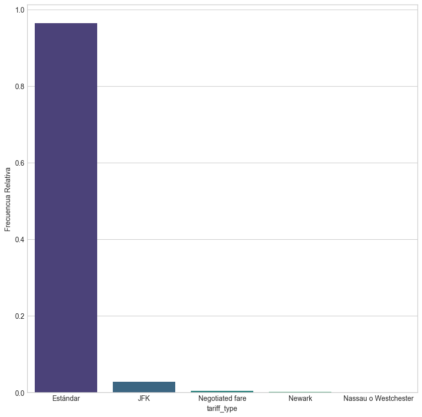

```python
# Vemos distribución de nuestro actual Target
distribucion_categorica_relativa(train_set, target)
```

```python
train_set[target].value_counts()
```

```
tariff_type
Estándar                38577
JFK                      1146
Negotiated fare           169
Newark                     98
Nassau o Westchester       10
Name: count, dtype: int64
```

Esta terriblemente desbalanceado, por lo que no esperemos que salga un buen modelo.

#### **Modelado**

```python
# Entreno un modelo de Regresión Lineal.
lgr = LogisticRegression(class_weight='balanced', n_jobs=-1) # Parametrizamos un poco
lgr.fit(X_train, y_train)
```

```
LogisticRegression(class_weight='balanced', n_jobs=-1)
```

```python
# Evaluación contra train
y_pred_train = lgr.predict(X_train)
print(classification_report(y_train, y_pred_train)) # Ejemplo clásico de Overfitting
```

```
                      precision    recall  f1-score   support

            Estándar       1.00      1.00      1.00     38577
                 JFK       0.89      1.00      0.94      1146
Nassau o Westchester       0.38      1.00      0.56        10
     Negotiated fare       0.92      1.00      0.96       169
              Newark       0.95      1.00      0.98        98

            accuracy                           1.00     40000
           macro avg       0.83      1.00      0.89     40000
        weighted avg       1.00      1.00      1.00     40000
```

```python
# Evaluación contra test
y_pred_test = lgr.predict(X_test)
print(classification_report(y_test, y_pred_test))
```

```
                      precision    recall  f1-score   support

            Estándar       1.00      0.99      1.00      9653
                 JFK       0.87      0.99      0.93       274
Nassau o Westchester       0.00      0.00      0.00         1
     Negotiated fare       0.80      0.76      0.78        42
              Newark       0.68      0.87      0.76        30

            accuracy                           0.99     10000
           macro avg       0.67      0.72      0.69     10000
        weighted avg       0.99      0.99      0.99     10000
```

Como hemos visto anteriormente, el target tiene un fuerte desbalanceo, especialmente en la clase Nassau o Westchester, que cuenta con muy pocos registros.

El modelo predice muy bien las clases mayoritarias, manteniendo métricas altas tanto en train como en test, lo que indica buena capacidad de generalización global.

Sin embargo, la predicción disminuye en las clases minoritarias debido a la escasez de datos, lo que limita la capacidad del modelo para aprender patrones representativos. Este comportamiento es esperable en problemas de clasificación multiclase altamente desbalanceados.

Por tanto, el modelo puede considerarse válido para las clases principales, aunque la predicción de clases raras requeriría técnicas adicionales como agrupación de clases o más datos.

### 5. **Comparación de modelos**

En este proyecto se han aplicado dos enfoques distintos:

- **Regresión lineal** para predecir una variable continua (`total_amount`)
- **Regresión logística** para predecir una variable categórica (`tariff_type`).

Aunque ambos modelos presentan buenas métricas, su idoneidad depende del tipo de problema que abordan.

La **regresión lineal** mostró un buen ajuste global (R2 alto), lo que indica que las variables seleccionadas explican gran parte de la variabilidad del precio total del viaje. Sin embargo, el análisis de residuos revela cierta dispersión creciente para valores altos, lo que sugiere que el modelo no captura completamente la variabilidad en viajes más largos o costosos. Aun así, resulta adecuado cuando el objetivo es estimar una magnitud continua e interpretar la relación entre variables.

Por otro lado, la **regresión logística** obtuvo una precisión global muy elevada, manteniendo buenas predicciones en las clases mayoritarias. No obstante, el fuerte desbalanceo del target limita su capacidad para predecir correctamente las clases minoritarias, especialmente aquellas con muy pocos ejemplos.

### 6. **Conclusión**

Tal y como se ha analizado en el apartado anterior, ambos modelos muestran un buen rendimiento dentro de su contexto. La **regresión lineal** presenta una alta capacidad para predecir el precio del viaje, mientras que la **regresión logística** consigue una elevada precisión en la clasificación del tipo de tarifa, aunque con limitaciones en las clases minoritarias debido al desbalanceo de los datos.

En relación con las variables más influyentes, y como ya se observó previamente, aquellas directamente vinculadas con las características del trayecto son las que mayor peso tienen en la predicción. Variables como la distancia del viaje, la duración y los componentes del coste del trayecto concentran la mayor capacidad explicativa, lo cual resulta coherente con la lógica del problema.

Considerando el objetivo principal del análisis, la **regresión lineal** sería el enfoque más adecuado para la predicción de variables continuas como el importe total del viaje, ofreciendo mayor estabilidad e interpretabilidad.

## PARTE 3: Regresión Lineal "From Scratch" (Datos Simulados)

**Objetivo:** Demostrar que entiendes la matemática detrás de `LinearRegression()` implementándola con NumPy.

Amplia con:

- **Predicción y evaluación** Utiliza tu implementación para:
  - Realizar predicciones
  - Calcular manualmente el **MSE** y el **R²**, sin usar funciones de Scikit-Learn.
- **Comparación con Scikit-Learn** Entrena un modelo `LinearRegression()` sobre los mismos datos y compara:
  - Coeficientes
  - Métricas de evaluación  
    Discute posibles diferencias numéricas.

```python
import numpy as np
import matplotlib.pyplot as plt

# --- NO TOCAR: GENERACIÓN DE DATOS ---
np.random.seed(42)
X_mock = 2 * np.random.rand(100, 1)
y_mock = 4 + 3 * X_mock + np.random.randn(100, 1)
# -----------------------------------

def evolve_linear_regression( X, y, iteraciones=8, eta=0.1 ):
    """
    Calcula la pendiente (w) y el intercepto (beta_0)
    usando las fórmulas de OLS con NumPy.
    Returns: (b, w)
    """
    # TU CÓDIGO AQUÍ
    #Generacion aleatoria de parametros (numpy) -> PASO 1
    w = np.random.randn()
    b = np.random.randn()

    for i in range(1, iteraciones):
        # calcular el error -> PASO 2
        # Primero se define la recta
        recta = w * X + b

        error = recta - y # Error

        # Antes de ajustar parámetros calculamos el gradiente
        dw = np.sum(error * X) *2 / len(X)
        db = np.sum((error) * 2 / len(X))

        #Ajustar parametros -> PASO 3
        w -= eta * dw
        b -= eta * db

        #pintar recta -> PASO 4
        pintar_recta(b,w)

    return b, w


def pintar_recta(b, w):
    plt.scatter(X_mock, y_mock, color='blue', label='Datos')
    plt.plot(X_mock, b + w * X_mock, color='red', label='Tu Regresión')
    plt.legend()
    plt.show()
```

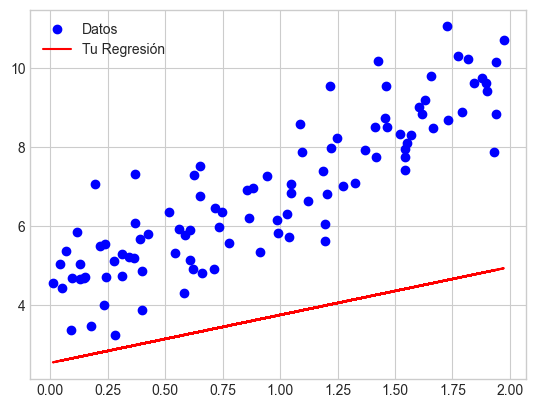

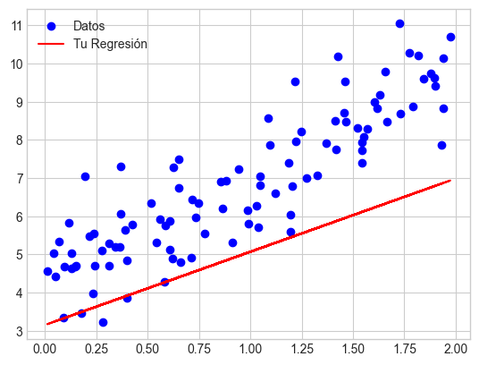

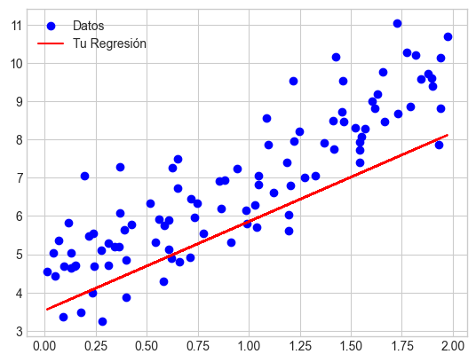

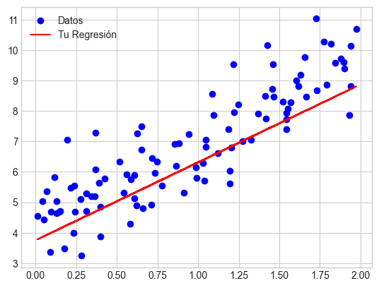

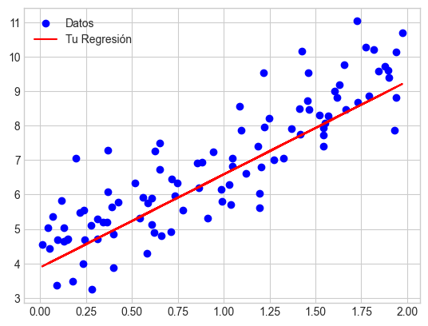

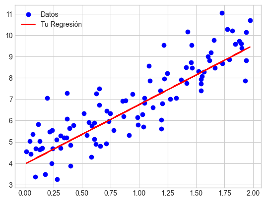

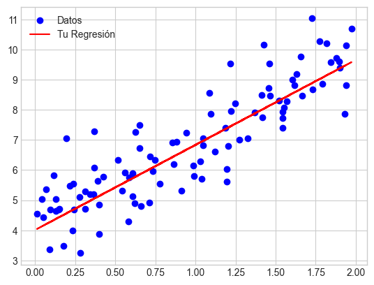

```
Intercepto estimado: 4.0088242753600865
Pendiente estimada: 2.8274849952418455
```

```python
# Probemos tu función
b0, b1 = evolve_linear_regression(X_mock, y_mock)
print(f"Intercepto estimado: {b0}")
print(f"Pendiente estimada: {b1}")
```

### 1. **Predicción y evaluación**

#### **Predicción**

```python
def predict(X, b, w):
    '''
    Predice según la ecucación de la recta.
        y^ = b + w * X

    Argumentos:
    b: Intercepto (dónde corta la reca el eje Y)
    w: Pendiente (cúanto cambia 'y' por cada unidad de X)
    y^: valor predicho
    '''
    prediction = b + w + X
    return prediction
```

```python
y_pred = predict(X_mock, b0, b1)
y_pred
```

```
array([[7.58538951],
       [8.73773788],
       [8.30029715],
       [8.03362624],
       [7.14834655],
       [7.14829831],
       [6.95247649],
       [8.56866156],
       [8.03853929],
       [8.25245443],
       [6.87747826],
       [8.77612897],
       [8.50119455],
       [7.26098749],
       [7.19995921],
       [7.20311829],
       [7.44479376],
       [7.88582213],
       [7.70019931],
       [7.41876755],
       [8.06001506],
       [7.11529699],
       [7.42059857],
       [7.56903296],
       [7.74844924],
       [8.40666119],
       [7.23565683],
       [7.86477815],
       [8.02113841],
       [6.9292101 ],
       [8.05139897],
       [7.17735752],
       [6.96641246],
       [8.73408035],
       [8.76757334],
       [8.45310397],
       [7.44553681],
       [7.0316535 ],
       [8.20477532],
       [7.71661426],
```

[output cut: 45 more lines]

```
       [7.48667591],
       [8.29552163],
       [8.11142421],
       [8.61073476],
       [7.78073912],
       [7.07549776],
       [8.26279885],
       [8.35787937],
       [7.95886367],
       [8.37824363],
       [7.82390046],
       [7.88177493],
       [7.69139131],
       [6.88714752],
       [7.05209212]])
```

#### **MSE manual**

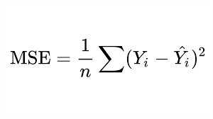

```python
def mse_manual(y_true, y_pred):
    mse = np.mean((y_true - y_pred) ** 2)
    return mse

mse_mn = mse_manual(y_mock, y_pred)
```

#### **R2 manual**

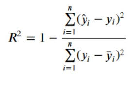

```python
def r2_manual(y_true, y_pred):
    up = np.sum((y_true - y_pred) ** 2)
    d = np.sum((y_true - np.mean(y_true)) ** 2)
    r2 = 1 - (up / d)
    return r2

r2_mn = r2_manual(y_mock, y_pred)
```

```python
print(f'MSE manual:', mse_mn)
print(f'R2 manual:', r2_mn)
```

```
MSE manual: 2.819891841479818
R2 manual: 0.19335964585229526
```

### 2. **Comparación con Scikit-Learn**

Entrena un modelo `LinearRegression()` sobre los mismos datos y compara:

- Coeficientes
- Métricas de evaluación  
  Discute posibles diferencias numéricas.

```python
# Entrenamiento
lr_3 = LinearRegression()
lr_3.fit(X_mock, y_mock)
```

```
LinearRegression()
```

```python
# Predicción
y_pred_sklearn = lr_3.predict(X_mock)
```

#### **Comparación de coeficientes**

```python
print("Intercepto (manual):", b0)
print("Intercepto (sklearn):", lr_3.intercept_[0])
print()
print("Pendiente (manual):", b1)
print("Pendiente (sklearn):", lr_3.coef_[0][0])
```

```
Intercepto (manual): 4.0088242753600865
Intercepto (sklearn): 4.215096157546747

Pendiente (manual): 2.8274849952418455
Pendiente (sklearn): 2.7701133864384837
```

#### **Comparación de métricas**

```python
print("MSE (manual):", mse_mn)
print("MSE (sklearn):", mean_squared_error(y_mock, y_pred_sklearn))
print()
print("R2 (manual):", r2_mn)
print("R2 (sklearn):", r2_score(y_mock, y_pred_sklearn))
```

```
MSE (manual): 2.819891841479818
MSE (sklearn): 0.8065845639670531

R2 (manual): 0.19335964585229526
R2 (sklearn): 0.7692735413614223
```

### 3. **Comparación de ambos modelos**

Al comparar la **implementación manual** de la regresión lineal mediante descenso por gradiente con el modelo `LinearRegression()` de **Scikit-Learn**, se observan diferencias tanto en los coeficientes estimados como en las métricas de evaluación.

El modelo **implementado manualmente** obtiene:

## PARTE 4: Series Temporales (Datos Simulados)

**Objetivo:** Analizar tendencias y estacionalidad en una serie temporal generada.

**Tareas:**

1. Convierte el índice a formato DateTime.
2. Haz un resampleo mensual (`'M'`) mostrando la media de ventas.
3. Calcula una **Media Móvil** de 3 meses para suavizar la curva.
4. Usa `seasonal_decompose` para visualizar los componentes (Tendencia, Estacionalidad y ruido).

Amplia Con:

- **Generación de la serie** Describe brevemente cómo se ha generado la serie temporal simulada, indicando si incluye tendencia, estacionalidad y ruido.
- **Comparación de suavizados** Calcula una segunda media móvil con una ventana distinta y compara visualmente ambos suavizados. Comenta las diferencias observadas.

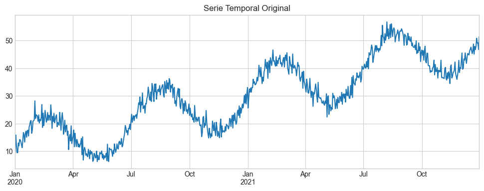

```python
from statsmodels.tsa.seasonal import seasonal_decompose

# --- NO TOCAR: GENERACIÓN DE DATOS TEMPORALES ---
dates = pd.date_range(start='2020-01-01', periods=365*2, freq='D')
values = np.linspace(10, 50, len(dates)) + 10 * np.sin(np.linspace(0, 3.14*8, len(dates))) + np.random.normal(0, 2, len(dates))
ts_df = pd.DataFrame({'Sales': values}, index=dates)
# -----------------------------------------------

# TU CÓDIGO AQUÍ

# 1. Plot inicial
ts_df['Sales'].plot(title='Serie Temporal Original', figsize=(12,4))
plt.show()
```

### 1. **Generación de la serie**

```
dates = pd.date_range(start='2020-01-01', periods=365*2, freq='D')
```

Se genera con el método **date_range()** de Pandas las fechas simuladas, empezando a partir del 2020, generando 2 años (`periods=365*2`) siendo la frecuencia de la generación por día (`freq='D'`)

```
values = np.linspace(10, 50, len(dates)) + 10 * np.sin(np.linspace(0, 3.14*8, len(dates))) + np.random.normal(0, 2, len(dates))
```

```
ts_df = pd.DataFrame({'Sales': values}, index=dates)
```

Esta última línea es la creación de un DataFrame, creando una columna llama Sales que corresponde a los valores y se ponen como indices las fechas

### 2. **Tareas**

#### **Convierte el índice a formato DateTime**

```python
# Echo un vistazo a los datos
ts_df.info()
```

```
<class 'pandas.core.frame.DataFrame'>
DatetimeIndex: 730 entries, 2020-01-01 to 2021-12-30
Freq: D
Data columns (total 1 columns):
 #   Column  Non-Null Count  Dtype
---  ------  --------------  -----
 0   Sales   730 non-null    float64
dtypes: float64(1)
memory usage: 11.4 KB
```

```python
ts_df.index # Ya es de tipo DateTime
```

```
DatetimeIndex(['2020-01-01', '2020-01-02', '2020-01-03', '2020-01-04',
               '2020-01-05', '2020-01-06', '2020-01-07', '2020-01-08',
               '2020-01-09', '2020-01-10',
               ...
               '2021-12-21', '2021-12-22', '2021-12-23', '2021-12-24',
               '2021-12-25', '2021-12-26', '2021-12-27', '2021-12-28',
               '2021-12-29', '2021-12-30'],
              dtype='datetime64[ns]', length=730, freq='D')
```